# Velocity structure and seismicity, catalog v5.1

Model v0.3.1, resolved nodes only. Catalog v5.1 with the v5.1 magnitudes, the v5.1 clustering and fault surfaces v1. 2026-11-25, revised the same day after an adversarial review (b-value statement, Q1 detection limit, controls of the Blanco node-scale result, multiple-testing families) and rerun on the fixed sibling products (clusters f904659b, faults 6ebe0230; v5.1 magnitudes with production M unchanged). Private working report; not peer reviewed. Code: `workflow/06_analysis/v51_struct*.py` on branch analysis/v51-struct; input versions and checksums in input_commits.json.

### Context since this analysis was built

- The PI adopted model v0.4.0 (v0.3.1 re-inverted with the re-timed picks, D-B082); v0.4.1 (with a surface floor in the inversion, D-B083) is being built. Catalog v6.0 (D-B079, NonLinLoc with SSST station terms) will supersede v5.1, and these v5.1 products will be redone on v6.0. Nothing here was rerun on v0.4.0, except that v0.4.0's Blanco tile (blanco_m0t, damping 200, smoothing 20) is one of the tile runs in section 6.
- Waveform review of four v5.1 location problems (catalog_v5/v5.1_review): **P1** Mount St Helens deep events, likely false (weekly artificial signal on analog UW channels): none of the 331 is in a resolved cell (all deeper than 30 km; Washington is resolved only to 18 km), but they set the 95th-percentile depth (D95) of the Mount St Helens column in Q3 (13 of its 141 well-constrained events; D95 54 km with them, 21 km without). 10 of the P1 shallow reference and Wednesday-window events are in Washington resolved cells at 1-9 km. **P2** Brookings 2012 (two depth solutions, NonLinLoc took about 56 km): none of the 39 is in a resolved cell; they make the two Gorda columns near Brookings with D95 58-63 km in Q3. **P3** tensor events (v5.1 a median 13.7 km deeper than ComCat): 10 in resolved cells (MTJ 5, BL 3, WA 2). **P4** far_only events (moved from near the surface in v4 to 44-64 km): 30 in resolved cells, 29 of them at the Blanco; the deep_pass events: 0.
- The magnitude piece found that its phase19 ML inversion stops before converging. Production M is unchanged (PI decision pending); converged, whole offshore regions would move (Blanco -0.68, Gorda and Mendocino -0.28, onshore +0.01). The b-value splits here compare events within one zone, so a regional shift does not change them to first order, but the set of events above the box Mc would change.

### Summary

- **Testable sample.** 11.0% of the 168,406 located earthquakes (18,560) are in cells where Vp passes the checkerboard tests, and 2.9% (4,825) where Vp and Vs both pass, so Vp/Vs can be read. All of the Vp/Vs cells are at the Blanco transform, at the 15 and 18 km nodes (a few at 29 km). Vp alone is resolved in three places: the Blanco at 15, 18 and 29 km, the Gorda slab under Cape Mendocino at 29 km, and southwest Washington (Mount St. Helens, 1-9 km; Puget and the Cascades foothills, 12-18 km). Summed over the resolved depth nodes, the resolved volume holds about 53 independent checkerboard cells for Vp and 14 for Vp/Vs. That is an upper bound: depth nodes 2-3 km apart (1-9 km at Mount St. Helens, 15 and 18 km at the Blanco) are counted as independent, although the 40-100 km checkerboards do not separate them. Counting only the largest layer of each zone gives 25 and 8.5 (the Blanco Vp/Vs layer is 8.5 cells at 15 km and 4.7 at 18 km). That cell count, not the number of events, limits every test below.
- **Q1, swarms against mainshock-aftershock sequences (Blanco only).** 24 swarm and 34 mainshock-aftershock families have members in Vp/Vs-resolved cells. Their median Vp/Vs values are 1.727 and 1.729. The coverage-matched difference is -0.003 (95% block bootstrap [-0.042, +0.136], permutation p 0.93). The families fall in 11 blocks of 40 km, the swarms in 4. The bootstrap interval sets what can be excluded: it has a half-width of 0.09, so differences from -0.04 to +0.14 are not excluded. That covers most of the 0.05-0.15 range of published differences between settings. (The permutation range, [-0.06, +0.06], treats neighbouring families as independent and is not a detection limit.) The data neither support nor exclude a fluid control of swarms.
- **Q2, where the events are (node scale).** At the Blanco, the nodes that hold events are slower than coverage and depth predict: -1.81% in Vp change ([-3.09, -0.23]) and -2.85% in Vs change ([-5.30, -0.06]), against [-0.97, +0.94]% and [-1.23, +1.13]% for randomized catalogs and [-0.45, +0.24]% and [-1.21, +0.52]% for the checkerboard inversion errors. **Four controls weaken it.** (a) With the catalog v4 hypocentres of the same events (not located in v0.3.1), the Vp part drops to -0.54% [-1.71, +0.39], and to -0.50% with v5.1 epicentres and v4 depths: the Vp signal comes from the v5.1 depths, which were computed in this model. The Vs part stays at -2.32% [-3.56, -0.43]. (b) Counting each occupied node once instead of each event gives only -0.40% and -0.35%: a few busy nodes carry it. (c) Its bootstrap interval excludes zero in 12/16 (Vp) and 10/16 (Vs) placements of the 40 km block grid, and in 11/16 and 7/16 with 60 km blocks; the stratified Spearman versions exclude zero in 15/16 and 16/16 at 40 km and 16/16 and 16/16 at 60 km. (d) The 8 Blanco tests that pass are 2 correlated signals (Vp and Vs), each counted four times (change and absolute value, each as an event-weighted mean and a Spearman correlation).
- **Q2 at the resolved scale.** With the field smoothed to the resolved scale (Gaussian, sigma 20 km), the anomaly is -0.25% ([-0.89, +0.24]) for Vp and -1.02% ([-2.40, +0.61]) for Vs; both intervals include zero. This smoothing is applied after the inversion. Blanco tile inversions that smooth more themselves keep most of the anomaly at the events in value, though their intervals include zero (smoothing 60: -1.52% [-2.76, +0.14] / -2.19% [-4.21, +0.17]; smoothing 120: -1.06% / -1.52%, Vp / Vs change), and v0.4.0's Blanco tile with the re-timed picks reproduces it (-1.77% / -2.86%, intervals excluding zero). The 40-100 km checkerboards certify neither scale. Under the rule that only resolved structure is interpreted, the Blanco result is not usable as structure. Vp/Vs at the events is not clearly higher (+0.025, [-0.014, +0.060]; smoothed +0.017, [-0.004, +0.032]). Nothing passes at the Mendocino triple junction or in Washington. At the Mendocino 29 km node the Vp change flips sign with well-constrained depths only (+0.71% for all events, -0.38% for depth_good): 40% of the resolved Mendocino events are depth_quality biased_deep.
- **Q2, b-value.** For all events above Mc, no split between slow and fast nodes passes (largest: Washington Vp +0.38 [-0.04, +0.65], p 0.050, q 0.26). **For background events only, the Washington Vp split passes the pass rule**: b is 1.30 below and 1.79 above the coverage-matched mean (difference +0.49 [+0.06, +0.76], p 0.002, q 0.013 in the primary family). It holds in both Mc boxes (Other onshore 1.15 vs 1.79, Puget 1.50 vs 1.79) and above Mc + 0.2 (1.28 vs 1.76); 334 of its 334 events have ML, and 0 are in a waveform-review set. By node depth: 1-9 km 1.60 vs 2.33, 12-18 km 1.23 vs 1.69. It is one pass among 20 b-value splits (10 of them background-only), and the same events split by Vp change do not differ (+0.17 [-0.12, +0.42]). A lead to recheck on catalog v6.0 and model v0.4.x, not a result.
- **Q3, depth extent.** A Vp level cannot be tested: only 6 Blanco columns, and 0-3 elsewhere, have resolved Vp on both nodes around their 90th-percentile depth. Against the slab (Slab2, no tomography needed): in the Mendocino box the deepest well-located events lie a median 11.3 km below the slab top and do not follow its shape more closely than random pairing. In the Puget and onshore boxes they stop 27-31 km above the slab. 5 Gorda-box columns have D95 deeper than 50 km where the slab is shallow or absent: 2 near Brookings (D95 58-63 km; review P2) and 3 at 40.5 N, 126.00-126.25 W (D95 55-59 km, no Slab2 there): possible depth errors.
- **Q4, fault surfaces v1.** 44 surfaces have at least 10 mesh vertices in Vp-resolved cells. Their normals are no more aligned with the horizontal Vp gradient than randomly rotated surfaces (mean alignment 0.70 against 0.66, p 0.15). They also do not sit at stronger gradients than other resolved nodes of the same coverage (median ratio 0.97, [0.79, 1.08]). The 10 stable surfaces give 0.78 against 0.68 (p 0.045); 6 of them are Blanco strands whose strike comes from a map-view band search, and v1_PU002 is not recovered in 3 of 3 detection reruns. At 40-60 km resolution a fault-scale contrast cannot be seen.
- **Q5, Blanco segments.** The two western segments (West Blanco and Surveyor Depressions) have the highest Vp/Vs at their events (1.77 and 1.77) and the highest swarm shares (0.70, 0.66). The Blanco Ridge has the lowest Vp/Vs (1.70) and a swarm share of 0.41. Over five segments the Spearman correlation is 0.67 with exact p 0.27. The segment values are not independent either: the two western medians are the same node value (1.766), and 11 nodes hold 616 events of two segments. A pattern to test with relocated swarms and a finer model, not a result.
- **Multiple tests.** The primary family has 87 tests (the 77 of the first version plus the 10 background-only b-value splits, which were computed and must be counted). 13 have a Benjamini-Hochberg q below 0.05; 9 also have a block-bootstrap interval that excludes the no-effect value and count as passed: 8 node-scale Blanco Q2 statistics (2 signals, Vp and Vs), and WA b(high Vp_res) - b(low), background only. With every computed variant added (193 tests; variant sets of Q1-Q3 and the Q5 area tests), 33 pass, all in the same 3 signals (Q2 BL Vp node scale 16; Q2 BL Vs node scale 16; Q2 WA b vs Vp background 1): the extra passes are the Blanco statistics repeated for depth_good, above-Mc and background events. None passes at the resolved scale. tests_summary.csv lists both families and a 'signal' column that groups tests measuring the same thing.

## 1. Data and selection

- Catalog v5.1: 172,342 rows. Rows without a hypocentre (loc_source none) are left out of every spatial analysis: 623. Located: 171,719. Non-earthquakes (ComCat explosions, quarry blasts, other events; Texada quarry_blast_likely; is_earthquake False in the v5.1 magnitudes) are left out: 3,313. That leaves 168,406 located earthquakes.
- Well-constrained depth (depth_good, the clusters piece's definition): tier A-C, depth_quality ok, not floor_limited, far_only or deep_pass: 98,204 events. Depth-sensitive variants use only these. Blanco depths outside the 2012-13 OBS deployment are depth_quality unconstrained, and the Blanco v5.1 depths are a median 2.9 km deeper than the Lange et al. (2026) OBS catalog (faults piece). Placement in the 15 or 18 km layer therefore depends on that bias.
- Flags of the events in Vp-resolved cells (flags_resolved_by_zone.csv): at the Blanco 34% have unconstrained depth, 19% are tier D (median h_max of these 28 km, i.e. more than half a bootstrap block) and 29 are far_only; at the Mendocino 29 km node 40% are biased_deep and 15% tier D; in Washington 21% are tier D (median h_max 36 km) and 60 floor_limited. The main tests use all located earthquakes and report depth_good variants. These agree at the Blanco (Vp change -1.97% [-3.28, -0.37]) but not at the Mendocino node (sign flip, +0.71% to -0.38%).
- Magnitudes: v5.1 M (mag piece; production M unchanged by its review fixes). Mc per box from the clusters piece (v4 rule on v5.1 magnitudes). Clustering: the v5.1 nearest-neighbour families (types swarm, mainshock-aftershock, multiplet) and their classes; family ids and types are unchanged by the clusters piece's review fixes. Fault surfaces v1: summary, assignment, and the 1 km mesh (constrained vertices only); the faults review fixes changed assignment labels (a new class for Axial, which has no resolved node) and surface flags, not the surfaces' geometry or stable flags.
- Model v0.3.1 (94 x 118 x 21 = 232,932 nodes, 0.125 x 0.1 deg, depth -3 to 125 km). Vp and its change are sampled where resolution_p > 0. Vs, Vp/Vs and their changes are all sampled on one node set, the nodes resolved for both phases (resolution_p > 0, resolution_s > 0 and vs_reverted = 0), so the Vs and Vp/Vs tests use the same nodes and strata. These are the D-B018 checkerboard criteria (local correlation >= 0.7 and amplitude >= 0.5 at 40, 60 or 100 km cells, with pick noise, both pattern phases), merged under D-B049, and D-B051 for Vs. Resolved nodes: 888 for P, 279 for S, 224 for both. The 55 nodes resolved for S but not P (holding 591 located earthquakes) are not used. Resolved nodes in water or air by the v0.3.2 medium flag: 0. The D-B073 shallow-crust rule is not in v0.3.1 and is not used. Only the medium flag is read from v0.3.2. The masks are empty at 21 and 25 km everywhere; at 12 km only 4 Washington nodes are resolved (holding 384 events), and offshore nothing is resolved above 13.5 km.
- An event belongs to the node nearest to its hypocentre (voxel boundaries halfway between nodes). A stricter variant requires all eight corners of the enclosing grid cell to be resolved: 6,383 events for Vp and 1,112 for Vp/Vs.

## 2. Method: controls for circularity

The events give the rays. Ray density (DWS) and resolution are therefore high where events are, and a tomographic error that follows the events would look like a structure-seismicity relation. The v5.1 hypocentres were also located in this model (plus the D-B073 shallow-crust rule), so a velocity error and a location error can trade off. Each test uses four controls:

1. **Coverage-matched anomaly.** Each resolved node gets a stratum: zone x depth node x DWS tercile (P DWS for Vp, S DWS for Vs and Vp/Vs). V_res is the node value minus the mean over the resolved nodes of its stratum. A relation in V_res cannot come from depth or from the amount of ray coverage alone. DWS quintiles give the same results (t2_density.csv, columns *_q5).
2. **Randomized catalogs.** The event set of each occupied node is moved to a random resolved node of the same stratum (2,000 times). This keeps the event clustering and the coverage. For Q1, family types are permuted among families of the same stratum. These node-level permutations treat neighbouring nodes as independent, so their ranges are too narrow and are not used as detection limits.
3. **Block bootstrap.** 95% intervals come from resampling 40 km blocks, the finest resolved checkerboard cell, with all events and nodes of a block together (2,000 resamples). This is the interval to read for the effect size. For the Blanco Q2 statistics the interval also depends on where the block grid falls (section 6, t2_block_offsets*.csv).
4. **Synthetic inversion errors.** The checkerboard inversions of each tile (40, 60 and 100 km cells; pick noise; pattern phases 0 and 1; and inversions started from perturbed hypocentres, noise_ploc) were run on the real event and station geometry. The error, recovered minus true, follows the events only through the inversion. The same statistics on these error fields give the size of an artefact.

Added after review, for the Blanco Q2 result: the catalog v4 hypocentres of the same events (not located in v0.3.1; v4 depths have their own problems, D-B057) sampled in the same model; each occupied node counted once; 16 placements of 40 and 60 km block grids; and the same statistic on Blanco tile inversions with stronger smoothing and with the re-timed picks. Each event's catalog errors (horizontal sqrt((h_min^2 + h_max^2)/2)/1.515, vertical sig_z) are resampled 50 times to test the sensitivity to location. None of this moves a hypocentre in any product. Multiple tests: Benjamini-Hochberg q within the primary family and over primary plus variants (tests_summary.csv, section 15).

## 3. Fraction of events in resolved cells

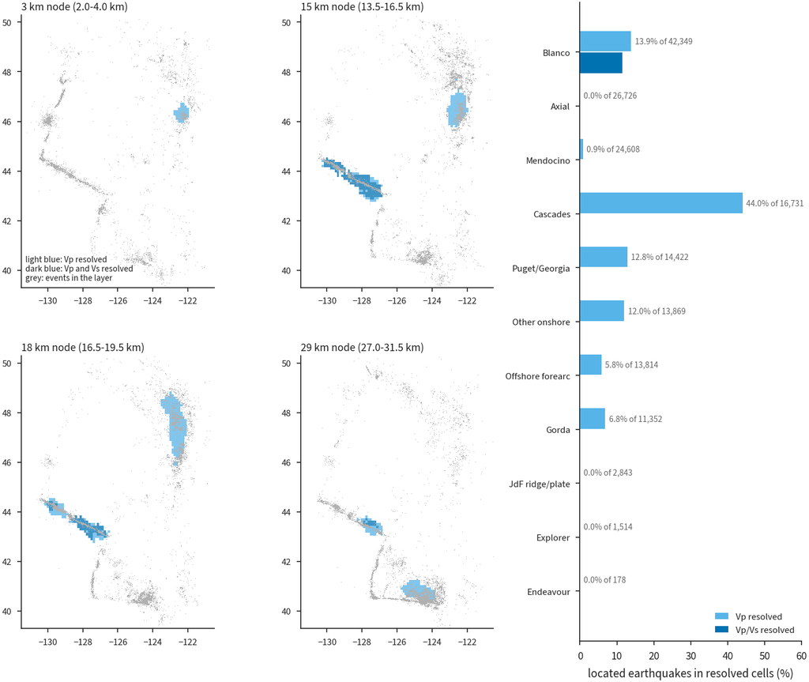

Left: resolved nodes at four depth nodes, with the events of each layer. Right: located earthquakes in resolved cells by catalog region.

By zone and depth node. ncell is the resolved area divided by the square of the finest resolved checkerboard cell: the number of independent velocity samples in that layer. Layers 2-3 km apart are not independent of each other, so the sum over layers is an upper bound.

| node_zone | node_depth | nodes_P | nodes_PS | area_P_km2 | ncell_P | ncell_PS | n_resP | n_resPS | n_depth_good | n_aboveMc |
| --- | --- | --- | --- | --- | --- | --- | --- | --- | --- | --- |
| BL | 15 | 160 | 134 | 1.791e+04 | 10.22 | 8.491 | 3000 | 2931 | 1699 | 454 |
| BL | 18 | 136 | 77 | 1.521e+04 | 8.351 | 4.732 | 2490 | 1846 | 1431 | 487 |
| BL | 29 | 50 | 13 | 5613 | 2.338 | 0.6379 | 391 | 48 | 84 | 89 |
| MTJ | 29 | 83 | 0 | 9707 | 5.298 |  | 1938 | 0 | 939 | 757 |
| WA | 1 | 20 | 0 | 2135 | 1.335 |  | 2267 | 0 | 1525 | 13 |
| WA | 3 | 38 | 0 | 4056 | 2.387 |  | 796 | 0 | 509 | 18 |
| WA | 5 | 51 | 0 | 5441 | 3.105 |  | 1161 | 0 | 934 | 50 |
| WA | 7 | 52 | 0 | 5547 | 3.245 |  | 925 | 0 | 717 | 53 |
| WA | 9 | 21 | 0 | 2239 | 1.399 |  | 828 | 0 | 680 | 18 |
| WA | 12 | 4 | 0 | 426.3 | 0.2665 |  | 384 | 0 | 343 | 8 |
| WA | 15 | 96 | 0 | 1.021e+04 | 5.572 |  | 1832 | 0 | 1602 | 79 |
| WA | 18 | 177 | 0 | 1.848e+04 | 9.747 |  | 2548 | 0 | 2177 | 298 |

| group | n | n_resP | pct_resP | n_resPS | pct_resPS | n_resP8 | n_resPS8 |
| --- | --- | --- | --- | --- | --- | --- | --- |
| all rows (incl. no hypocentre) | 172342 | 18675 | 10.8 | 4825 | 2.8 | 6424 | 1112 |
| located (loc_source nll3d/comcat) | 171719 | 18675 | 10.9 | 4825 | 2.81 | 6424 | 1112 |
| located earthquakes | 168406 | 18560 | 11 | 4825 | 2.87 | 6383 | 1112 |
| located earthquakes, depth_good | 98204 | 12640 | 12.9 | 2828 | 2.88 | 4626 | 755 |
| located earthquakes, M >= Mc of box | 30201 | 2324 | 7.7 | 847 | 2.8 | 485 | 185 |
| class: background | 136627 | 14406 | 10.5 | 3580 | 2.62 | 5104 | 875 |
| class: mainshock-aftershock | 14637 | 1521 | 10.4 | 328 | 2.24 | 174 | 82 |
| class: swarm | 8501 | 1483 | 17.4 | 632 | 7.43 | 646 | 56 |
| class: multiplet | 3714 | 346 | 9.32 | 148 | 3.98 | 149 | 52 |
| class: linked_to_single | 4927 | 804 | 16.3 | 137 | 2.78 | 310 | 47 |
| fault assignment: ambiguous | 26257 | 3412 | 13 | 974 | 3.71 | 1284 | 173 |
| fault assignment: assigned | 12651 | 1207 | 9.54 | 308 | 2.43 | 284 | 60 |
| fault assignment: fit member | 64272 | 10944 | 17 | 3311 | 5.15 | 4342 | 834 |
| fault assignment: non-earthquake timing (weekday-daytime member of a surface removed for its timing) | 884 | 1 | 0.113 | 0 | 0 | 0 | 0 |
| fault assignment: none | 37468 | 2996 | 8 | 232 | 0.619 | 473 | 45 |
| fault assignment: not fitted (Axial Seamount left out) | 26874 | 0 | 0 | 0 | 0 | 0 | 0 |

Swarm events are over-represented in Vp/Vs-resolved cells (7.4% against 2.9% overall). The Blanco swarms are what resolves the 15-18 km layer. Events on no fault surface (assignment none, now only in fitted regions) are under-represented (0.6%). Nothing is resolved at Axial, Endeavour, Explorer or the Juan de Fuca ridge and plate, in Gorda above 29 km, or in the offshore Oregon and Washington forearc.

Catalog flags and waveform-review sets of the events in resolved cells:

| mask | zone | n | pct_tier_D | pct_depth_unconstrained | pct_depth_biased_deep | pct_depth_good | n_far_only | n_deep_pass | n_floor_limited | n_review_P1_deep | n_review_P1_other | n_review_P2 | n_review_P3 | n_review_P4_far_only | n_review_P4_deep_pass | n_ml_caution | tierD_h_max_med_km | sig_z_med_km |
| --- | --- | --- | --- | --- | --- | --- | --- | --- | --- | --- | --- | --- | --- | --- | --- | --- | --- | --- |
| resP | BL | 5881 | 18.6 | 33.8 | 0 | 54.7 | 29 | 0 | 0 | 0 | 0 | 0 | 3 | 29 | 0 | 9 | 27.8 | 5.44 |
| resP | MTJ | 1938 | 15 | 0 | 39.6 | 48.5 | 1 | 0 | 0 | 0 | 0 | 0 | 5 | 1 | 0 | 12 | 19.1 | 3.71 |
| resP | WA | 10741 | 21 | 0 | 0 | 79 | 0 | 0 | 60 | 0 | 10 | 0 | 2 | 0 | 0 | 32 | 35.8 | 1.96 |
| resPS | BL | 4825 | 17.8 | 29.9 | 0 | 58.6 | 18 | 0 | 0 | 0 | 0 | 0 | 3 | 18 | 0 | 4 | 28.9 | 5.25 |

## 4. The Blanco at 15 and 18 km

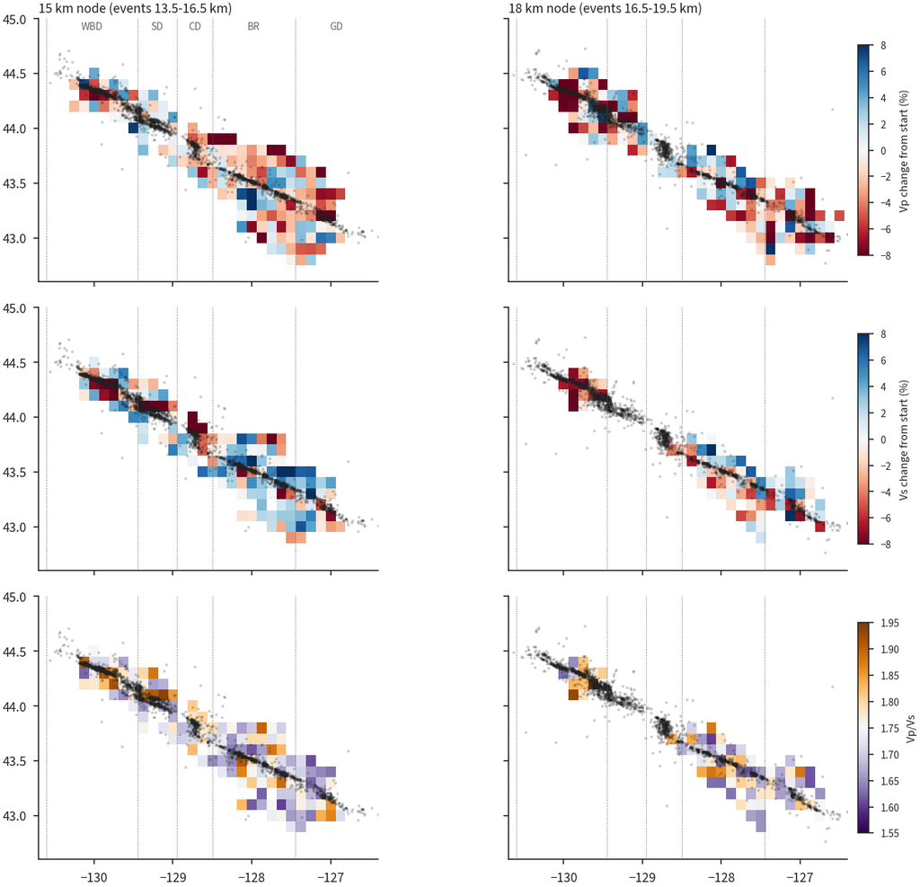

Resolved nodes only: Vp change, Vs change and Vp/Vs at the 15 and 18 km nodes, with the events of each layer and the segment boundaries used in Q5.

Vp at these nodes is 7.1-8.4 km/s (5th-95th percentile; median 7.83), i.e. uppermost mantle velocities, and the Vp change from the start spans -10.9 to +5.2%. Vp/Vs at the 224 Vp/Vs-resolved nodes spans 1.62-1.88 (5th-95th percentile), with a median of 1.73. The starting model there is Kuna et al. (2019) 1-D, with Vp/Vs 1.73 in the mantle. Lange et al. (2026) report Vp/Vs above 2 in most of the fault zone, but higher up, in the crust; our model does not resolve the crust at the Blanco.

## 5. Q1: swarms and mainshock-aftershock sequences in different Vp/Vs settings?

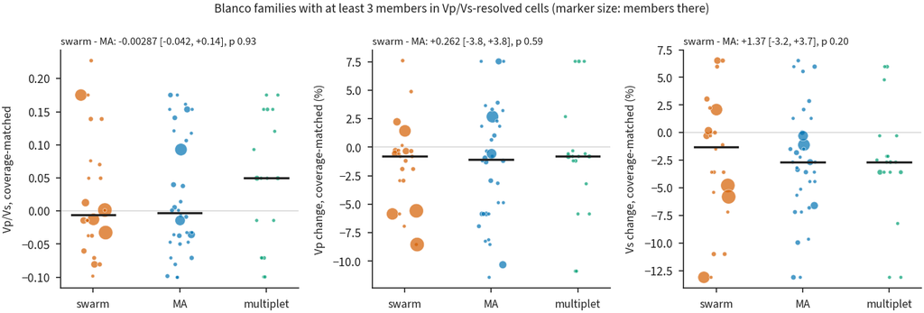

Coverage-matched Vp/Vs, Vp change and Vs change of each Blanco family (median over the members in Vp/Vs-resolved cells), by family type. Bars: medians.

| set | zone | var | contrast | n_swarm | n_other | n_blocks | med_swarm | med_other | diff | ci_lo | ci_hi | null_lo | null_hi | p_perm |
| --- | --- | --- | --- | --- | --- | --- | --- | --- | --- | --- | --- | --- | --- | --- |
| resPS | BL | VpVs | swarm - mainshock-aftershock | 24 | 34 | 11 | 1.73 | 1.73 | -0.00192 | -0.0456 | 0.136 | -0.065 | 0.0566 | 0.95 |
| resPS | BL | VpVs | swarm - multiplet | 24 | 18 | 11 | 1.73 | 1.78 | -0.0554 | -0.192 | 0.00929 | -0.0741 | 0.0666 | 0.132 |
| resPS | BL | VpVs_res | swarm - mainshock-aftershock | 24 | 34 | 11 | -0.00589 | -0.00302 | -0.00287 | -0.0417 | 0.136 | -0.0611 | 0.0611 | 0.934 |
| resPS | BL | VpVs_res | swarm - multiplet | 24 | 18 | 11 | -0.00589 | 0.0495 | -0.0554 | -0.168 | 0.0213 | -0.0671 | 0.0741 | 0.155 |
| resPS | BL | dVpVs_res | swarm - mainshock-aftershock | 24 | 34 | 11 | 0.241 | 0.423 | -0.183 | -2.36 | 6.59 | -2.89 | 2.83 | 0.895 |
| resPS | BL | dVpVs_res | swarm - multiplet | 24 | 18 | 11 | 0.241 | 2.72 | -2.48 | -8.37 | 0 | -3.78 | 3.74 | 0.179 |
| resPS | BL | dVs_res | swarm - mainshock-aftershock | 24 | 34 | 11 | -1.3 | -2.67 | 1.37 | -3.19 | 3.71 | -1.57 | 2.28 | 0.197 |
| resPS | BL | dVs_res | swarm - multiplet | 24 | 18 | 11 | -1.3 | -2.67 | 1.37 | -2.94 | 4.86 | -3.18 | 2.09 | 0.317 |
| resPS | BL | dVp_res | swarm - mainshock-aftershock | 24 | 34 | 11 | -0.805 | -1.07 | 0.262 | -3.77 | 3.83 | -1.76 | 1.03 | 0.586 |
| resPS | BL | dVp_res | swarm - multiplet | 24 | 18 | 11 | -0.805 | -0.805 | 0 | -9.45 | 1.29 | -1.97 | 2.03 | 1 |
| resPS_dg | BL | VpVs | swarm - mainshock-aftershock | 11 | 26 | 10 | 1.73 | 1.74 | -0.00227 | -0.0867 | 0.149 | -0.103 | 0.128 | 0.964 |
| resPS_dg | BL | VpVs | swarm - multiplet | 11 | 10 | 10 | 1.73 | 1.82 | -0.084 | -0.239 | 0.0895 | -0.16 | 0.136 | 0.278 |
| resPS_dg | BL | VpVs_res | swarm - mainshock-aftershock | 11 | 26 | 10 | 0.000938 | 0.0032 | -0.00227 | -0.0919 | 0.145 | -0.099 | 0.132 | 0.915 |
| resPS_dg | BL | VpVs_res | swarm - multiplet | 11 | 10 | 10 | 0.000938 | 0.0849 | -0.084 | -0.214 | 0.0619 | -0.155 | 0.136 | 0.286 |
| resPS_dg | BL | dVpVs_res | swarm - mainshock-aftershock | 11 | 26 | 10 | -1.53 | 0.916 | -2.45 | -6.96 | 8.83 | -4.73 | 6 | 0.272 |
| resPS_dg | BL | dVpVs_res | swarm - multiplet | 11 | 10 | 10 | -1.53 | 4 | -5.53 | -12.3 | 3.77 | -8.42 | 6.55 | 0.223 |
| resPS_dg | BL | dVs_res | swarm - mainshock-aftershock | 11 | 26 | 10 | -3.58 | -2.24 | -1.34 | -8.33 | 5.28 | -4.59 | 4.22 | 0.447 |
| resPS_dg | BL | dVs_res | swarm - multiplet | 11 | 10 | 10 | -3.58 | -2.67 | -0.909 | -8.33 | 9.19 | -5.37 | 4.93 | 0.781 |
| resPS_dg | BL | dVp_res | swarm - mainshock-aftershock | 11 | 26 | 10 | -1.91 | -0.767 | -1.15 | -4.4 | 2.82 | -5.23 | 1.62 | 0.569 |
| resPS_dg | BL | dVp_res | swarm - multiplet | 11 | 10 | 10 | -1.91 | -2.2 | 0.288 | -9.45 | 3.51 | -5.51 | 2.92 | 0.916 |
| resPS_strict | BL | VpVs | swarm - mainshock-aftershock | 6 | 17 | 8 | 1.68 | 1.72 | -0.0452 | -0.184 | 0.0557 | -0.12 | 0.0938 | 0.443 |
| resPS_strict | BL | VpVs | swarm - multiplet | 6 | 15 | 8 | 1.68 | 1.78 | -0.104 | -0.247 | -0.0512 | -0.108 | 0.11 | 0.093 |
| resPS_strict | BL | VpVs_res | swarm - mainshock-aftershock | 6 | 17 | 8 | -0.049 | -0.00887 | -0.0401 | -0.177 | 0.0665 | -0.115 | 0.116 | 0.58 |
| resPS_strict | BL | VpVs_res | swarm - multiplet | 6 | 15 | 8 | -0.049 | 0.0495 | -0.0984 | -0.235 | -0.0435 | -0.109 | 0.126 | 0.113 |
| resPS_strict | BL | dVpVs_res | swarm - mainshock-aftershock | 6 | 17 | 8 | -2.82 | -1.67 | -1.15 | -8.18 | 4.24 | -7.97 | 7.37 | 0.784 |
| resPS_strict | BL | dVpVs_res | swarm - multiplet | 6 | 15 | 8 | -2.82 | 2.72 | -5.54 | -14.8 | -2.9 | -7.68 | 7.51 | 0.193 |
| resPS_strict | BL | dVs_res | swarm - mainshock-aftershock | 6 | 17 | 8 | 1.52 | -5.67 | 7.2 | -1.43 | 12 | -3.38 | 7.34 | 0.029 |
| resPS_strict | BL | dVs_res | swarm - multiplet | 6 | 15 | 8 | 1.52 | -2.67 | 4.19 | 2.02 | 15.5 | -4.34 | 6.36 | 0.145 |
| resPS_strict | BL | dVp_res | swarm - mainshock-aftershock | 6 | 17 | 8 | -0.572 | -5.85 | 5.28 | -1.22 | 5.99 | -4.66 | 4.11 | 0.0105 |
| resPS_strict | BL | dVp_res | swarm - multiplet | 6 | 15 | 8 | -0.572 | -0.805 | 0.233 | -7.85 | 4.22 | -5.05 | 4.85 | 0.827 |
| resP | BL | dVp_res | swarm - mainshock-aftershock | 28 | 38 | 11 | -1 | -0.992 | -0.00773 | -3.9 | 3.77 | -1.41 | 1.57 | 0.935 |
| resP | BL | dVp_res | swarm - multiplet | 28 | 21 | 11 | -1 | -0.805 | -0.194 | -9.45 | 1.29 | -1.47 | 2.35 | 0.821 |
| resP | WA | dVp_res | swarm - mainshock-aftershock | 15 | 21 | 9 | -0.645 | -0.645 | 0 | -0.628 | 1.18 | -1.03 | 1.06 | 1 |
| resP | WA | dVp_res | swarm - multiplet | 15 | 14 | 9 | -0.645 | -2.08 | 1.43 | -0.734 | 3.31 | -0.913 | 1.47 | 0.036 |
| resP_dg | BL | dVp_res | swarm - mainshock-aftershock | 12 | 27 | 10 | -1.91 | -0.339 | -1.57 | -4.61 | 2.82 | -2.51 | 3.65 | 0.343 |
| resP_dg | BL | dVp_res | swarm - multiplet | 12 | 12 | 10 | -1.91 | -2.56 | 0.647 | -9.45 | 3.53 | -2.93 | 4.8 | 0.741 |
| resP_dg | WA | dVp_res | swarm - mainshock-aftershock | 12 | 16 | 9 | -0.0414 | -1.08 | 1.04 | -0.557 | 1.73 | 0.0881 | 1.45 | 0.614 |
| resP_dg | WA | dVp_res | swarm - multiplet | 12 | 13 | 9 | -0.0414 | -2.91 | 2.87 | -0.693 | 4.02 | 0.791 | 3.33 | 0.452 |
| resP_strict | BL | dVp_res | swarm - mainshock-aftershock | 7 | 21 | 9 | -0.805 | -3.16 | 2.35 | -3.49 | 5.54 | -5.05 | 3.88 | 0.185 |
| resP_strict | BL | dVp_res | swarm - multiplet | 7 | 17 | 9 | -0.805 | -0.805 | 0 | -7.85 | 2.9 | -5.05 | 3.41 | 1 |
| resP_strict | WA | dVp_res | swarm - mainshock-aftershock | 8 | 13 | 7 | -1.27 | -1.25 | -0.0247 | -1.28 | 1.22 | -0.418 | 1.32 | 0.856 |
| resP_strict | WA | dVp_res | swarm - multiplet | 8 | 10 | 7 | -1.27 | -1.14 | -0.128 | -1.56 | 2.47 | -1.38 | 0.674 | 0.598 |

Set resPS: families with at least 3 members in Vp/Vs-resolved cells. resPS_dg: the same with well-constrained depths only. resPS_strict: at least half of the members in resolved cells (this drops the large Blanco swarms, whose members spread over the unresolved 12 and 21 km layers). resP: Vp only, Blanco and Washington. Main result: Vp/Vs swarm minus mainshock-aftershock -0.003 [-0.042, +0.136]; depth_good only -0.002 [-0.092, +0.145]; strict -0.040 [-0.177, +0.066]. With location errors resampled, the difference stays between -0.027 and +0.021 (5-95%). Vp and Vs changes: +0.26% [-3.77, +3.83] and +1.37% [-3.19, +3.71]. What can be excluded is set by the bootstrap interval (half-width 0.09 in Vp/Vs), not by the permutation range (null_lo, null_hi).

Event level (events above Mc in Vp/Vs-resolved cells): the swarm share of clustered events in nodes above and below the coverage-matched mean.

| zone | var | n_low | n_high | clustered_low | clustered_high | swarm_share_low | swarm_share_high | bg_share_low | bg_share_high | diff_swarm_share | ci_lo | ci_hi |
| --- | --- | --- | --- | --- | --- | --- | --- | --- | --- | --- | --- | --- |
| BL | VpVs_res | 353 | 494 | 176 | 267 | 0.5 | 0.629 | 0.501 | 0.46 | 0.129 | -0.317 | 0.307 |
| BL | dVpVs_res | 434 | 413 | 223 | 220 | 0.641 | 0.514 | 0.486 | 0.467 | -0.128 | -0.316 | 0.134 |
| BL | dVp_res | 572 | 275 | 289 | 154 | 0.557 | 0.617 | 0.495 | 0.44 | 0.0598 | -0.262 | 0.189 |
| BL | dVs_res | 623 | 224 | 321 | 122 | 0.548 | 0.656 | 0.485 | 0.455 | 0.107 | -0.0298 | 0.298 |

Family labels at the Blanco (clusters piece, null test after its review): a catalog shuffled in time over the whole period reproduces 39% of the Blanco nearest-neighbour links (same-month shuffles 62-92% across regions), but only 12.8 swarms on average against 70 in the real catalog. Part of the mainshock-aftershock and multiplet labelling is therefore not robust; the swarms are.

## 6. Q2: seismicity density and b-value against Vp/Vs and Vp change at fixed depth and coverage

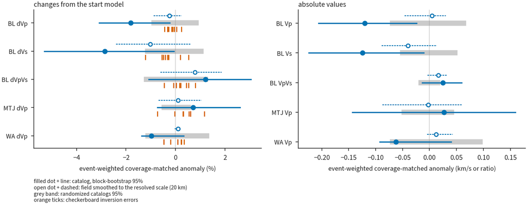

Mean coverage-matched anomaly at the events (each event counts once), by zone and variable. Blue: catalog with its block-bootstrap 95% interval. Grey band: 95% range of the randomized catalogs. Orange ticks: the same statistic on each checkerboard inversion error field (9 per zone).

| events | zone | var | n_nodes | n_nodes_with_events | n_events | n_blocks | rho_depth_only | rho_cov | rho_ci_lo | rho_ci_hi | rho_p | event_mean_res | res_ci_lo | res_ci_hi | res_null_lo | res_null_hi | res_p | event_mean_res_q5 | occ_mean_res | occ_ci_lo | occ_ci_hi |
| --- | --- | --- | --- | --- | --- | --- | --- | --- | --- | --- | --- | --- | --- | --- | --- | --- | --- | --- | --- | --- | --- |
| all | BL | Vp | 346 | 207 | 5881 | 26 | -0.0384 | -0.216 | -0.341 | -0.0463 | 0.0005 | -0.12 | -0.206 | -0.0242 | -0.0734 | 0.0682 | 0.000999 | -0.126 | -0.0319 | -0.0859 | 0.016 |
| all | BL | dVp | 346 | 207 | 5881 | 26 | -0.058 | -0.179 | -0.283 | -0.0162 | 0.0005 | -1.81 | -3.09 | -0.231 | -0.968 | 0.943 | 0.0005 | -1.83 | -0.397 | -0.928 | 0.225 |
| all | MTJ | Vp | 83 | 73 | 1938 | 11 | 0.0959 | -0.0721 | -0.312 | 0.329 | 0.539 | 0.0269 | -0.143 | 0.159 | -0.0521 | 0.0455 | 0.282 | 0.0212 | -0.00913 | -0.109 | 0.0636 |
| all | MTJ | dVp | 83 | 73 | 1938 | 11 | -0.0855 | -0.000462 | -0.229 | 0.333 | 0.998 | 0.71 | -0.739 | 2.61 | -0.562 | 0.613 | 0.0155 | 0.689 | 0.0298 | -0.828 | 0.996 |
| all | WA | Vp | 459 | 373 | 10741 | 27 | 0.129 | 0.0403 | -0.143 | 0.208 | 0.42 | -0.0622 | -0.0924 | 0.0404 | -0.0735 | 0.0985 | 0.133 | -0.0756 | 0.00543 | -0.0278 | 0.0395 |
| all | WA | dVp | 459 | 373 | 10741 | 27 | -0.0509 | 0.0226 | -0.144 | 0.17 | 0.671 | -0.979 | -1.36 | 0.326 | -1.22 | 1.36 | 0.144 | -1.01 | 0.0278 | -0.114 | 0.276 |
| all | BL | VpVs | 224 | 143 | 4825 | 20 | 0.0672 | 0.134 | -0.0241 | 0.297 | 0.063 | 0.0247 | -0.0139 | 0.0598 | -0.0206 | 0.02 | 0.02 | 0.0266 | 0.00291 | -0.0149 | 0.022 |
| all | BL | dVpVs | 224 | 143 | 4825 | 20 | 0.0939 | 0.128 | -0.0249 | 0.319 | 0.0705 | 1.21 | -1.08 | 3.05 | -1.29 | 1.32 | 0.0725 | 1.38 | 0.253 | -0.917 | 1.52 |
| all | BL | Vs | 224 | 143 | 4825 | 20 | -0.195 | -0.323 | -0.475 | -0.133 | 0.0005 | -0.125 | -0.224 | -0.0107 | -0.0545 | 0.0522 | 0.0005 | -0.129 | -0.0166 | -0.0776 | 0.0341 |
| all | BL | dVs | 224 | 143 | 4825 | 20 | -0.231 | -0.307 | -0.466 | -0.113 | 0.0005 | -2.85 | -5.3 | -0.0639 | -1.23 | 1.13 | 0.0005 | -2.87 | -0.348 | -1.87 | 0.882 |
| all, field smoothed 20 km | BL | Vp | 346 | 207 | 5881 | 26 |  | -0.132 |  |  |  | 0.00463 | -0.0465 | 0.0302 | -0.0206 | 0.0181 | 0.636 |  |  |  |  |
| all, field smoothed 20 km | MTJ | Vp | 83 | 73 | 1938 | 11 |  | -0.207 |  |  |  | -0.00269 | -0.0875 | 0.0611 | -0.0315 | 0.0266 | 0.855 |  |  |  |  |
| all, field smoothed 20 km | WA | Vp | 459 | 373 | 10741 | 27 |  | 0.118 |  |  |  | 0.0122 | -0.00429 | 0.0431 | -0.016 | 0.0152 | 0.131 |  |  |  |  |
| all, field smoothed 20 km | BL | dVp | 346 | 207 | 5881 | 26 |  | -0.195 |  |  |  | -0.247 | -0.885 | 0.243 | -0.267 | 0.301 | 0.0855 |  |  |  |  |
| all, field smoothed 20 km | MTJ | dVp | 83 | 73 | 1938 | 11 |  | -0.243 |  |  |  | 0.106 | -0.69 | 1.04 | -0.251 | 0.258 | 0.451 |  |  |  |  |
| all, field smoothed 20 km | WA | dVp | 459 | 373 | 10741 | 27 |  | 0.036 |  |  |  | 0.0993 | -0.0321 | 0.145 | -0.119 | 0.124 | 0.121 |  |  |  |  |
| all, field smoothed 20 km | BL | VpVs | 224 | 143 | 4825 | 20 |  | 0.285 |  |  |  | 0.0168 | -0.00402 | 0.0324 | -0.00635 | 0.00693 | 0.0005 |  |  |  |  |
| all, field smoothed 20 km | BL | dVpVs | 224 | 143 | 4825 | 20 |  | 0.235 |  |  |  | 0.785 | -0.614 | 1.86 | -0.499 | 0.488 | 0.0005 |  |  |  |  |
| all, field smoothed 20 km | BL | Vs | 224 | 143 | 4825 | 20 |  | -0.35 |  |  |  | -0.0403 | -0.089 | 0.0139 | -0.019 | 0.017 | 0.0005 |  |  |  |  |
| all, field smoothed 20 km | BL | dVs | 224 | 143 | 4825 | 20 |  | -0.227 |  |  |  | -1.02 | -2.4 | 0.611 | -0.521 | 0.477 | 0.0005 |  |  |  |  |

rho_depth_only: Spearman correlation between the event count of a node and the raw value, within zone x depth (coverage not matched). rho_cov: the same on the coverage-matched anomaly, averaged over strata. event_mean_res: the mean anomaly at the events. occ_mean_res: the same with each occupied node counted once. Units: % for changes, km/s for Vp and Vs, ratio for Vp/Vs. The rows for well-constrained depths, events above Mc and background events only are in t2_density.csv (variant family). Their Blanco values have the same sign and size, e.g. depth_good Vp change -1.97% [-3.28, -0.37]. At the Mendocino node they do not: +0.71% for all events, -0.38% [-1.10, +0.58] for depth_good.

**Reading.** At the node scale, Blanco nodes with more events are slower in Vp and Vs at the same depth and coverage: -1.8% (Vp) and -2.9% (Vs). That is about 4 and 2 times the largest checkerboard artefact, and the inversions started from perturbed hypocentres do not give larger artefacts. It survives the location Monte Carlo at a smaller size (-1.34% and -1.95%) and DWS quintiles. The checkerboard errors use true hypocentres and random perturbations; they do not simulate a systematic depth error such as the v5.1 Blanco depth bias. The controls below show how much of it depends on choices that the checkerboards do not test.

### Control 1: catalog v4 hypocentres in the same model

| positions | mask | var | n_events | n_nodes_with_events | n_blocks | event_mean_res | res_ci_lo | res_ci_hi | res_null_lo | res_null_hi | res_p | occ_mean_res | rho_cov |
| --- | --- | --- | --- | --- | --- | --- | --- | --- | --- | --- | --- | --- | --- |
| v5.1 (all located earthquakes) | resP | Vp | 5881 | 207 | 26 | -0.12 | -0.206 | -0.0242 | -0.0732 | 0.0731 | 0.0005 | -0.0319 | -0.216 |
| v5.1 (all located earthquakes) | resP | dVp | 5881 | 207 | 26 | -1.81 | -3.09 | -0.231 | -1.04 | 0.961 | 0.0005 | -0.397 | -0.179 |
| v5.1 (all located earthquakes) | resPS | VpVs | 4825 | 143 | 20 | 0.0247 | -0.0139 | 0.0598 | -0.0201 | 0.0218 | 0.0165 | 0.00291 | 0.134 |
| v5.1 (all located earthquakes) | resPS | dVpVs | 4825 | 143 | 20 | 1.21 | -1.08 | 3.05 | -1.29 | 1.33 | 0.077 | 0.253 | 0.128 |
| v5.1 (all located earthquakes) | resPS | Vs | 4825 | 143 | 20 | -0.125 | -0.224 | -0.0107 | -0.0586 | 0.0511 | 0.0005 | -0.0166 | -0.323 |
| v5.1 (all located earthquakes) | resPS | dVs | 4825 | 143 | 20 | -2.85 | -5.3 | -0.0639 | -1.23 | 1.18 | 0.0005 | -0.348 | -0.307 |
| v5.1 (events with a v4 hypocentre) | resP | Vp | 5881 | 207 | 26 | -0.12 | -0.206 | -0.0242 | -0.0677 | 0.0681 | 0.002 | -0.0319 | -0.216 |
| v5.1 (events with a v4 hypocentre) | resP | dVp | 5881 | 207 | 26 | -1.81 | -3.09 | -0.231 | -0.979 | 0.923 | 0.0005 | -0.397 | -0.179 |
| v5.1 (events with a v4 hypocentre) | resPS | VpVs | 4825 | 143 | 20 | 0.0247 | -0.0139 | 0.0598 | -0.0199 | 0.0211 | 0.018 | 0.00291 | 0.134 |
| v5.1 (events with a v4 hypocentre) | resPS | dVpVs | 4825 | 143 | 20 | 1.21 | -1.08 | 3.05 | -1.33 | 1.27 | 0.072 | 0.253 | 0.128 |
| v5.1 (events with a v4 hypocentre) | resPS | Vs | 4825 | 143 | 20 | -0.125 | -0.224 | -0.0107 | -0.0535 | 0.0515 | 0.0005 | -0.0166 | -0.323 |
| v5.1 (events with a v4 hypocentre) | resPS | dVs | 4825 | 143 | 20 | -2.85 | -5.3 | -0.0639 | -1.21 | 1.18 | 0.0005 | -0.348 | -0.307 |
| v4 | resP | Vp | 5726 | 203 | 26 | -0.0475 | -0.158 | 0.0497 | -0.0877 | 0.0822 | 0.276 | -0.0283 | -0.217 |
| v4 | resP | dVp | 5726 | 203 | 26 | -0.537 | -1.71 | 0.387 | -1.24 | 1.13 | 0.363 | -0.278 | -0.16 |
| v4 | resPS | VpVs | 4917 | 143 | 20 | 0.0291 | -0.011 | 0.0656 | -0.0225 | 0.0269 | 0.023 | 0.00927 | 0.195 |
| v4 | resPS | dVpVs | 4917 | 143 | 20 | 2.12 | -0.34 | 3.68 | -1.62 | 1.65 | 0.012 | 0.631 | 0.206 |
| v4 | resPS | Vs | 4917 | 143 | 20 | -0.0903 | -0.141 | -0.0181 | -0.0699 | 0.0696 | 0.012 | -0.0208 | -0.334 |
| v4 | resPS | dVs | 4917 | 143 | 20 | -2.32 | -3.56 | -0.434 | -1.61 | 1.56 | 0.0045 | -0.39 | -0.32 |
| v4 epicentre, v5.1 depth | resP | Vp | 5894 | 203 | 26 | -0.0999 | -0.191 | -0.00372 | -0.0686 | 0.0679 | 0.0045 | -0.0264 | -0.201 |
| v4 epicentre, v5.1 depth | resP | dVp | 5894 | 203 | 26 | -1.57 | -2.97 | 0.188 | -0.906 | 0.908 | 0.002 | -0.352 | -0.182 |
| v4 epicentre, v5.1 depth | resPS | VpVs | 4781 | 140 | 20 | 0.0255 | -0.0119 | 0.0596 | -0.0196 | 0.0206 | 0.0115 | 0.0105 | 0.221 |
| v4 epicentre, v5.1 depth | resPS | dVpVs | 4781 | 140 | 20 | 1.23 | -1.01 | 3.06 | -1.26 | 1.23 | 0.056 | 0.606 | 0.189 |
| v4 epicentre, v5.1 depth | resPS | Vs | 4781 | 140 | 20 | -0.12 | -0.222 | -0.00866 | -0.0507 | 0.0492 | 0.0005 | -0.0216 | -0.333 |
| v4 epicentre, v5.1 depth | resPS | dVs | 4781 | 140 | 20 | -2.76 | -5.23 | 0.0109 | -1.21 | 1.17 | 0.0005 | -0.44 | -0.314 |
| v5.1 epicentre, v4 depth | resP | Vp | 5699 | 209 | 26 | -0.0399 | -0.146 | 0.0593 | -0.0988 | 0.0818 | 0.367 | -0.0335 | -0.202 |
| v5.1 epicentre, v4 depth | resP | dVp | 5699 | 209 | 26 | -0.498 | -1.64 | 0.471 | -1.24 | 1.21 | 0.408 | -0.451 | -0.168 |
| v5.1 epicentre, v4 depth | resPS | VpVs | 4925 | 151 | 20 | 0.0271 | -0.0103 | 0.0652 | -0.0252 | 0.0291 | 0.0475 | 0.00872 | 0.189 |
| v5.1 epicentre, v4 depth | resPS | dVpVs | 4925 | 151 | 20 | 1.97 | -0.264 | 3.51 | -1.62 | 1.79 | 0.0265 | 0.606 | 0.235 |
| v5.1 epicentre, v4 depth | resPS | Vs | 4925 | 151 | 20 | -0.0812 | -0.138 | -0.0157 | -0.076 | 0.0664 | 0.0285 | -0.0274 | -0.356 |
| v5.1 epicentre, v4 depth | resPS | dVs | 4925 | 151 | 20 | -2.13 | -3.48 | -0.401 | -1.75 | 1.64 | 0.0125 | -0.592 | -0.362 |

The v4 hypocentres (GraphDD, catalog v4) were not located in v0.3.1. Restricted to the same events, the v5.1 positions give -1.81% (Vp change) and -2.85% (Vs change); the v4 positions give -0.54% [-1.71, +0.39] and -2.32% [-3.56, -0.43]. v4 epicentres with v5.1 depths give -1.57% and v5.1 epicentres with v4 depths -0.50% (Vp) and -2.13% (Vs). The Vp association follows the v5.1 depths, which were computed in this model, so it may be a velocity-depth trade-off; the Vs association does not depend on which hypocentres are used. Rows for Mendocino and Washington are in t2_v4hypo.csv. This is also the v4 counterpart on our own tomography that the first version said did not exist. The v4 depths are not publishable (D-B057), so this control says which coordinate carries the signal, not which depth is right.

### Control 2: block-grid placement

| var | block_km | n_placements | w_excludes_0 | w_ci_hi_min | w_ci_hi_max | s_excludes_0 | s_ci_hi_min | s_ci_hi_max |
| --- | --- | --- | --- | --- | --- | --- | --- | --- |
| Vp | 40 | 16 | 15 | -0.0581 | 0.0357 | 16 | -0.116 | -0.00941 |
| Vp | 60 | 16 | 12 | -0.0651 | 0.0131 | 16 | -0.146 | -0.0623 |
| Vs | 40 | 16 | 14 | -0.0309 | 0.00268 | 16 | -0.185 | -0.102 |
| Vs | 60 | 16 | 14 | -0.0343 | 0.0139 | 16 | -0.168 | -0.0736 |
| dVp | 40 | 16 | 12 | -0.795 | 0.569 | 15 | -0.0808 | 0.0204 |
| dVp | 60 | 16 | 11 | -0.751 | 0.724 | 16 | -0.0993 | -0.027 |
| dVs | 40 | 16 | 10 | -0.56 | 0.372 | 16 | -0.137 | -0.0856 |
| dVs | 60 | 16 | 7 | -0.452 | 0.683 | 16 | -0.143 | -0.0555 |

16 placements of the bootstrap block grid (origin shifted by 0, 1/4, 1/2 and 3/4 of a block in x and y) for 40 and 60 km blocks. w_excludes_0: placements where the interval of the event-weighted anomaly excludes zero; s_excludes_0: the same for the stratified Spearman correlation. The event-weighted interval depends on where the grid falls; the rank correlation does not. All placements: t2_block_offsets.csv.

### Control 3: tile inversions with stronger smoothing and with re-timed picks

| tile | run | note | var | n_nodes | n_events | event_mean_res | res_ci_lo | res_ci_hi | node_sd | corr_with_v031 |
| --- | --- | --- | --- | --- | --- | --- | --- | --- | --- | --- |
| blanco_m0 | d200_s20 | the run merged into v0.3.1 | dVp | 346 | 5881 | -1.82 | -3.09 | -0.23 | 5.14 | 0.998 |
| blanco_m0 | d200_s20 | the run merged into v0.3.1 | dVs | 224 | 4825 | -2.85 | -5.3 | -0.0629 | 4.53 | 1 |
| blanco_m0 | d200_s60 | smoothing 60 | dVp | 346 | 5881 | -1.52 | -2.76 | 0.14 | 4.14 | 0.886 |
| blanco_m0 | d200_s60 | smoothing 60 | dVs | 224 | 4825 | -2.19 | -4.21 | 0.171 | 3.39 | 0.869 |
| blanco_m0 | d200_s120 | smoothing 120 | dVp | 346 | 5881 | -1.06 | -2.16 | 0.403 | 3.28 | 0.743 |
| blanco_m0 | d200_s120 | smoothing 120 | dVs | 224 | 4825 | -1.52 | -2.83 | 0.0992 | 2.56 | 0.715 |
| blanco_m0t | d200_s20 | re-timed picks; the Blanco tile of v0.4.0 | dVp | 346 | 5881 | -1.77 | -3.03 | -0.205 | 5.02 | 0.971 |
| blanco_m0t | d200_s20 | re-timed picks; the Blanco tile of v0.4.0 | dVs | 224 | 4825 | -2.86 | -5.28 | -0.0528 | 4.52 | 0.995 |
| blanco_m0t | d200_s60 | re-timed picks, smoothing 60 | dVp | 346 | 5881 | -1.45 | -2.71 | 0.162 | 4.21 | 0.887 |
| blanco_m0t | d200_s60 | re-timed picks, smoothing 60 | dVs | 224 | 4825 | -2.17 | -4.2 | 0.19 | 3.38 | 0.868 |
| blanco_m0tnf | d200_s20 | re-timed picks, start from the margin_m0_v3nf reference | dVp | 346 | 5881 | -1.93 | -3.17 | -0.304 | 5.14 | 0.975 |
| blanco_m0tnf | d200_s20 | re-timed picks, start from the margin_m0_v3nf reference | dVs | 224 | 4825 | -2.91 | -5.35 | -0.093 | 4.53 | 0.994 |

The same event-weighted statistic on the v0.3.1 Blanco resolved nodes and strata, with the field of each tile run (trilinear from the tile lattice, interior nodes). blanco_m0 d200_s20 is the run merged into v0.3.1; blanco_m0t d200_s20 is the Blanco tile of v0.4.0. Stronger smoothing inside the inversion keeps 53-84% of the anomaly at the events in value (with intervals that then include zero) and lowers the node spread (node_sd); the post-hoc Gaussian smoothing removes most of it. So 'only at the single-node scale' was too strong: the anomaly sits at 10-40 km, below or at the finest checkerboard cell, and the 40-100 km checkerboards certify neither. The verifier's nearest-node mapping gave similar values (smoothing 60 -1.71/-2.19, smoothing 120 -1.19/-1.49, re-timed -2.04/-2.89).

### Resolved scale

Rows 'all, field smoothed 20 km' in t2_density.csv and open markers in the figure. The node-to-node spread of the Vp change at the Blanco is 4.9%, but only 1.2% after the Gaussian smoothing. For the smoothed Vp/Vs and Vs, the randomized catalogs give p < 0.001 while the block bootstrap includes zero; a smoothed field is strongly autocorrelated, so the node permutation is too narrow there, and the bootstrap is the interval to read. Ten-kilometre structure at the Blanco may be real (a damaged or hydrated transform mantle) or a trade-off with the v5.1 depths (control 1).

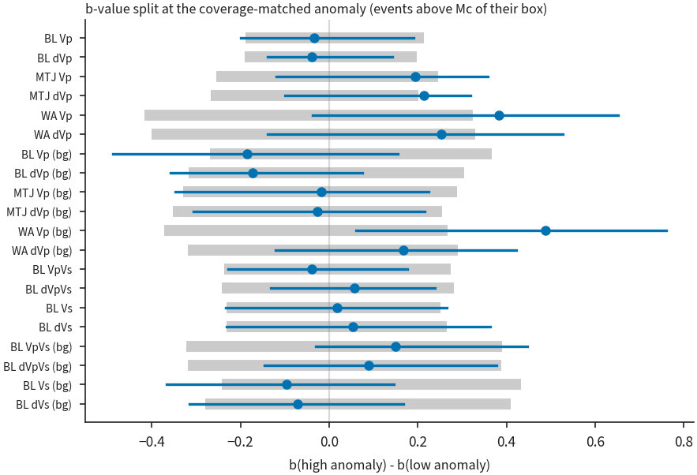

b-value difference between events in nodes above and below the coverage-matched mean, with block-bootstrap 95% intervals and the randomized-node null (grey).

| mask | events | zone | var | n_low | n_high | b_low | b_high | db_high_minus_low | ci_lo | ci_hi | null_lo | null_hi | p_perm | n_blocks | mc_boxes |
| --- | --- | --- | --- | --- | --- | --- | --- | --- | --- | --- | --- | --- | --- | --- | --- |
| resP | all above Mc | BL | Vp | 658 | 372 | 1.32 | 1.28 | -0.0339 | -0.199 | 0.191 | -0.188 | 0.214 | 0.764 | 18 | BL;GO |
| resP | all above Mc | BL | dVp | 668 | 362 | 1.32 | 1.28 | -0.0393 | -0.139 | 0.143 | -0.19 | 0.197 | 0.709 | 18 | BL;GO |
| resP | all above Mc | MTJ | Vp | 197 | 560 | 0.884 | 1.08 | 0.195 | -0.119 | 0.359 | -0.254 | 0.246 | 0.14 | 11 | GO;MT |
| resP | all above Mc | MTJ | dVp | 253 | 504 | 0.889 | 1.1 | 0.213 | -0.0996 | 0.319 | -0.267 | 0.201 | 0.087 | 11 | GO;MT |
| resP | all above Mc | WA | Vp | 286 | 251 | 1.24 | 1.62 | 0.383 | -0.0364 | 0.651 | -0.416 | 0.325 | 0.0505 | 18 | ON;PU |
| resP | all above Mc | WA | dVp | 318 | 219 | 1.3 | 1.55 | 0.253 | -0.138 | 0.527 | -0.4 | 0.33 | 0.207 | 18 | ON;PU |
| resP | background | BL | Vp | 340 | 173 | 1.62 | 1.44 | -0.185 | -0.487 | 0.156 | -0.268 | 0.367 | 0.274 | 18 | BL;GO |
| resP | background | BL | dVp | 343 | 170 | 1.62 | 1.44 | -0.173 | -0.357 | 0.0745 | -0.317 | 0.304 | 0.284 | 18 | BL;GO |
| resP | background | MTJ | Vp | 128 | 152 | 1.07 | 1.05 | -0.0172 | -0.347 | 0.225 | -0.33 | 0.289 | 0.918 | 11 | GO;MT |
| resP | background | MTJ | dVp | 146 | 134 | 1.08 | 1.05 | -0.0272 | -0.306 | 0.215 | -0.352 | 0.254 | 0.884 | 11 | GO;MT |
| resP | background | WA | Vp | 158 | 176 | 1.3 | 1.79 | 0.489 | 0.0615 | 0.761 | -0.372 | 0.268 | 0.002 | 17 | ON;PU |
| resP | background | WA | dVp | 187 | 147 | 1.45 | 1.62 | 0.167 | -0.121 | 0.423 | -0.318 | 0.29 | 0.297 | 17 | ON;PU |
| resPS | all above Mc | BL | VpVs | 353 | 494 | 1.41 | 1.37 | -0.0384 | -0.227 | 0.177 | -0.236 | 0.274 | 0.778 | 15 | BL |
| resPS | all above Mc | BL | dVpVs | 434 | 413 | 1.36 | 1.42 | 0.0568 | -0.131 | 0.239 | -0.243 | 0.282 | 0.677 | 15 | BL |
| resPS | all above Mc | BL | Vs | 651 | 196 | 1.39 | 1.4 | 0.0181 | -0.233 | 0.266 | -0.232 | 0.251 | 0.89 | 15 | BL |
| resPS | all above Mc | BL | dVs | 623 | 224 | 1.38 | 1.43 | 0.0544 | -0.232 | 0.363 | -0.232 | 0.265 | 0.679 | 15 | BL |
| resPS | background | BL | VpVs | 177 | 227 | 1.7 | 1.85 | 0.149 | -0.0293 | 0.447 | -0.323 | 0.39 | 0.425 | 15 | BL |
| resPS | background | BL | dVpVs | 211 | 193 | 1.74 | 1.83 | 0.0895 | -0.145 | 0.377 | -0.318 | 0.389 | 0.631 | 15 | BL |
| resPS | background | BL | Vs | 316 | 88 | 1.81 | 1.71 | -0.0966 | -0.367 | 0.147 | -0.242 | 0.433 | 0.638 | 15 | BL |
| resPS | background | BL | dVs | 302 | 102 | 1.8 | 1.73 | -0.071 | -0.314 | 0.168 | -0.278 | 0.41 | 0.744 | 15 | BL |

b uses the Aki-Utsu estimator on M minus the Mc of the event's box (pooled excess magnitudes). The background-only rows are part of the primary test family. **Washington, background events, Vp:** b 1.30 below and 1.79 above the coverage-matched mean, +0.49 [+0.06, +0.76], p 0.002, q 0.013: it passes. The first version of this report said that b does not differ in any zone; that was wrong for this row. Checks (t2_bvalue_checks.csv, point values):

| split_by | group | mc_plus | n_low | n_high | b_low | b_high | db_high_minus_low | n_ML | n_review |
| --- | --- | --- | --- | --- | --- | --- | --- | --- | --- |
| all | all | 0 | 158 | 176 | 1.3 | 1.79 | 0.489 | 334 | 0 |
| all | all | 0.2 | 86 | 76 | 1.28 | 1.76 | 0.475 | 162 | 0 |
| box | ON | 0 | 80 | 45 | 1.15 | 1.79 | 0.64 | 125 | 0 |
| box | ON | 0.2 | 47 | 18 | 1.15 |  |  | 65 | 0 |
| box | PU | 0 | 78 | 131 | 1.5 | 1.79 | 0.292 | 209 | 0 |
| box | PU | 0.2 | 39 | 58 | 1.49 | 1.81 | 0.322 | 97 | 0 |
| node depth | 1-9 km | 0 | 38 | 36 | 1.6 | 2.33 | 0.723 | 74 | 0 |
| node depth | 1-9 km | 0.2 | 16 | 12 |  |  |  | 28 | 0 |
| node depth | 12-18 km | 0 | 120 | 140 | 1.23 | 1.69 | 0.462 | 260 | 0 |
| node depth | 12-18 km | 0.2 | 70 | 64 | 1.27 | 1.7 | 0.429 | 134 | 0 |

Offshore b-values carry the magnitude piece's open problem: its phase19 ML inversion stops before converging. With the stored (production) M, ComCat ML gaps on anchors with at least 3 near picks are +0.59 at the Blanco, +0.33 at Gorda and +0.54 at Mendocino; converged, they would be +0.10, +0.02 and +0.26, with whole offshore regions moving (Blanco -0.68, Gorda and Mendocino -0.28, onshore +0.01). Within one zone a uniform shift does not change b, but D-B041 still asks for an ML-Mw check before b is compared between settings, and none is attempted here.

## 7. Q3: does the depth extent of seismicity follow a Vp level or the slab?

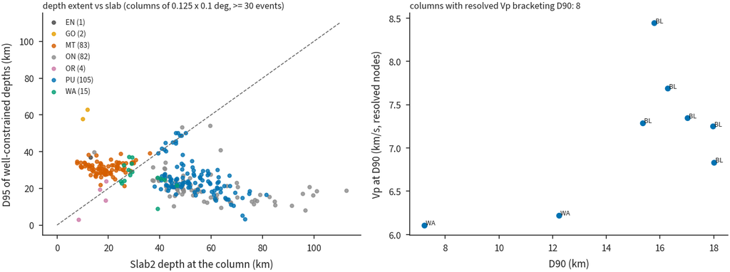

Left: 95th-percentile depth of well-constrained events in each model column with at least 30 of them, against the Slab2 depth. Right: Vp at the 90th-percentile depth, only where both bracketing depth nodes are resolved.

| test | zone | n_columns | n_blocks | median | sd_real | sd_ci_lo | sd_ci_hi | sd_null_med | sd_null_lo | sd_null_hi | p_smaller | depth_sd | rho_d95_slab | frac_d95_below_slab |
| --- | --- | --- | --- | --- | --- | --- | --- | --- | --- | --- | --- | --- | --- | --- |
| Vp level at d90 | BL | 6 | 5 | 7.32 | 0.499 | 0.138 | 0.72 | 0.308 | 0.125 | 0.497 | 0.976 | 1.02 |  |  |
| Vp level at d90 | MTJ | 0 |  |  |  |  |  |  |  |  |  |  |  |  |
| Vp level at d90 | WA | 2 |  |  |  |  |  |  |  |  |  |  |  |  |
| Vp level at d90 | other | 0 |  |  |  |  |  |  |  |  |  |  |  |  |
| Vp level at d95 | BL | 1 |  |  |  |  |  |  |  |  |  |  |  |  |
| Vp level at d95 | MTJ | 0 |  |  |  |  |  |  |  |  |  |  |  |  |
| Vp level at d95 | WA | 3 |  |  |  |  |  |  |  |  |  |  |  |  |
| Vp level at d95 | other | 0 |  |  |  |  |  |  |  |  |  |  |  |  |
| slab: sd(D95 - slab) | MT | 83 | 12 | 11.3 | 6.64 | 4.49 | 8.15 | 6.85 | 6.2 | 7.46 | 0.252 | 3.28 | 0.0272 | 0.988 |
| slab: sd(D95 - slab) | ON | 82 | 28 | -30.7 | 22.6 | 17 | 28.4 | 19.8 | 17.9 | 21.2 | 1 | 8.08 | -0.616 | 0.0244 |
| slab: sd(D95 - slab) | PU | 105 | 21 | -27 | 16.5 | 12.3 | 20 | 13.4 | 12 | 14.6 | 1 | 9.43 | -0.488 | 0.0762 |
| slab: sd(D95 - slab) | WA | 15 | 8 | -0.997 | 11.7 | 6.96 | 14.6 | 9.67 | 7.01 | 12.1 | 0.936 | 6.82 | -0.157 | 0.333 |
| slab: sd(D95 - slab) | ON (without review P1/P2) | 82 | 28 | -31.4 | 22.4 | 16.7 | 28.1 | 19.4 | 17.8 | 20.7 | 1 | 7.22 | -0.637 | 0.0244 |

| box | upper plate (>10 km above) | 3-10 km above | within 3 km | 3-10 km below | >10 km below | n |
| --- | --- | --- | --- | --- | --- | --- |
| EN | 0 | 0 | 1 | 5 | 31 | 37 |
| GO | 123 | 54 | 20 | 11 | 106 | 314 |
| MT | 606 | 2061 | 5949 | 6499 | 6253 | 21368 |
| ON | 17582 | 99 | 133 | 166 | 246 | 18226 |
| OR | 257 | 173 | 83 | 29 | 51 | 593 |
| PU | 10106 | 27 | 191 | 142 | 22 | 10488 |
| WA | 1413 | 176 | 376 | 316 | 79 | 2360 |

The Vp-level question is untestable on the resolved model. The checkerboards resolve isolated depth nodes (1-9, 15, 18 and 29 km; at 12 km only four Washington nodes; nothing at 21 and 25 km, which the tomography notes attribute to the vertical checker pattern). Almost no column has resolved nodes on both sides of its seismicity bottom. The 6 Blanco columns do not show a common Vp at D90 (spread larger than for depths placed in other columns). For the slab: in the Mendocino box, D95 is below the slab top in almost every column, and D95 minus slab depth spreads as much as with randomly paired columns. In the Puget and onshore boxes, D95 is shallower where the slab is deeper (Spearman -0.49 and -0.62). Upper-plate seismicity there ends at a crustal depth, not at the slab.

**Columns with D95 deeper than 50 km** (possible depth errors where the slab is shallow or absent):

| iy | ix | lon | lat | box | zone | n | d50 | d95 | slab_km | n_review_P1deep | n_review_P2 |
| --- | --- | --- | --- | --- | --- | --- | --- | --- | --- | --- | --- |
| 16 | 44 | -126.2 | 40.5 | GO | MTJ | 91 | 28.25 | 58.92 |  | 0 | 0 |
| 16 | 45 | -126.1 | 40.5 | GO | MTJ | 82 | 28.54 | 55.88 |  | 0 | 0 |
| 16 | 46 | -126 | 40.5 | GO | MTJ | 59 | 29.13 | 54.94 |  | 0 | 0 |
| 33 | 56 | -124.8 | 42.2 | GO | other | 38 | 48.24 | 57.69 | 10.03 | 0 | 29 |
| 33 | 57 | -124.6 | 42.2 | GO | other | 41 | 1.862 | 62.94 | 11.71 | 0 | 10 |
| 72 | 76 | -122.2 | 46.1 | ON | WA | 141 | 10.52 | 54.09 | 59.53 | 13 | 0 |
| 84 | 73 | -122.6 | 47.3 | PU | WA | 52 | 21.67 | 50.07 | 46.23 | 0 | 0 |
| 91 | 72 | -122.8 | 48 | PU | WA | 55 | 14.72 | 50.1 | 47.05 | 0 | 0 |
| 94 | 72 | -122.8 | 48.3 | PU | WA | 36 | 21.04 | 50.1 | 50.06 | 0 | 0 |
| 98 | 69 | -123.1 | 48.7 | ON | WA | 39 | 19.6 | 53.37 | 48.56 | 0 | 0 |

The 2 Gorda-box columns near Brookings (42.2 N) hold the 2012 swarm (review P2: predicted S-P is not monotonic with depth in the v5.1 grids, so about 7-9 km and about 56 km both fit the distant stations, and NonLinLoc took the deep one). The 3 Gorda-box columns at 40.5 N, west of the triple junction, have D95 55-59 km with no Slab2 there; they are not in a review set and should be checked the same way. The Mount St Helens column at 46.10 N, 122.250 W has D95 54 km with 13 of its 141 well-constrained events in the review's P1 deep set (likely false events); without them it is 21 km. Without the P1 and P2 events (variant family):

| test | zone | n_columns | n_blocks | median | sd_real | sd_ci_lo | sd_ci_hi | sd_null_med | sd_null_lo | sd_null_hi | p_smaller | depth_sd | rho_d95_slab | frac_d95_below_slab |
| --- | --- | --- | --- | --- | --- | --- | --- | --- | --- | --- | --- | --- | --- | --- |
| slab: sd(D95 - slab) | ON (without review P1/P2) | 82 | 28 | -31.4 | 22.4 | 16.7 | 28.1 | 19.4 | 17.8 | 20.7 | 1 | 7.22 | -0.637 | 0.0244 |

## 8. Q4: do fault surfaces v1 align with velocity contrasts?

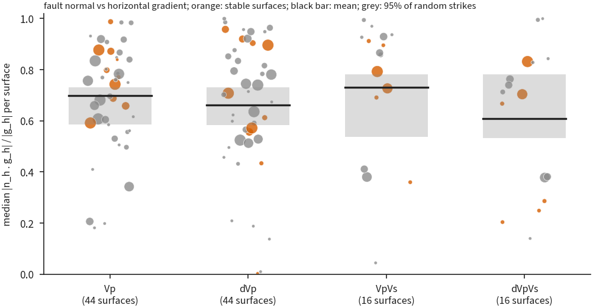

Per surface: median alignment between the horizontal surface normal and the horizontal gradient of Vp, Vp change, Vp/Vs and Vp/Vs change at its constrained mesh vertices in resolved cells. 1 = the gradient is perpendicular to the surface (the surface follows a contrast). Black bar: mean over surfaces; grey band: 95% range of that mean when every surface is rotated to a random strike.

| var | subset | n_surfaces | n_blocks | align_mean | align_ci_lo | align_ci_hi | align_null_mean | align_null_lo | align_null_hi | align_p_greater | frac_surfaces_p05 | grad_ratio_med | grad_ratio_ci_lo | grad_ratio_ci_hi | contrast_20km_med |
| --- | --- | --- | --- | --- | --- | --- | --- | --- | --- | --- | --- | --- | --- | --- | --- |
| Vp | all | 44 | 19 | 0.698 | 0.639 | 0.765 | 0.658 | 0.585 | 0.731 | 0.152 | 0.0227 | 0.971 | 0.795 | 1.08 | 0.157 |
| Vp | stable | 10 | 7 | 0.783 | 0.707 | 0.855 | 0.675 | 0.544 | 0.797 | 0.045 | 0.1 | 0.9 | 0.685 | 1.1 | 0.247 |
| VpVs | all | 16 | 6 | 0.731 | 0.467 | 0.871 | 0.66 | 0.536 | 0.781 | 0.138 | 0 | 0.957 | 0.848 | 1.51 | 0.0841 |
| VpVs | stable | 6 | 3 | 0.73 | 0.36 | 0.904 | 0.668 | 0.483 | 0.834 | 0.263 | 0 | 1.12 | 0.848 | 1.86 | 0.081 |
| dVp | all | 44 | 19 | 0.662 | 0.568 | 0.747 | 0.658 | 0.582 | 0.731 | 0.476 | 0.0682 | 1.04 | 0.667 | 1.21 | 1.83 |
| dVp | stable | 10 | 7 | 0.656 | 0.44 | 0.812 | 0.669 | 0.526 | 0.803 | 0.584 | 0.1 | 1.19 | 0.547 | 1.26 | 3.29 |
| dVpVs | all | 16 | 6 | 0.608 | 0.377 | 0.773 | 0.658 | 0.532 | 0.781 | 0.776 | 0.0625 | 1.18 | 0.966 | 1.4 | 5.61 |
| dVpVs | stable | 6 | 3 | 0.49 | 0.204 | 0.734 | 0.665 | 0.473 | 0.834 | 0.964 | 0 | 1.04 | 0.308 | 1.84 | 4.12 |

Gradients are central differences between resolved nodes only (about 10-11 km apart). The model resolves 40-60 km cells, so it can show only whether a surface runs along a long-wavelength velocity boundary. Neither the absolute Vp (which includes the starting model's lateral structure) nor the Vp change shows alignment. Orientation is used for all surfaces, but 93 of the 142 surfaces are unstable under detection reruns (strike range median 103 deg, against 6.5 deg for the 49 stable ones; faults piece). The 'stable' rows, 10 surfaces for Vp, are the only ones whose orientation can be trusted. Their alignment is 0.78 against 0.68 (p 0.04; q 0.24 after the correction for multiple tests), on 10 surfaces in 7 blocks. 6 of them are Blanco strands (strike from a map-view band search; no recovery test); v1_PU002 is not recovered in 3 of 3 detection reruns. Flags of every surface used are in t4_surfaces.csv (column flags).

## 9. Q5: region-specific questions

### Blanco segments

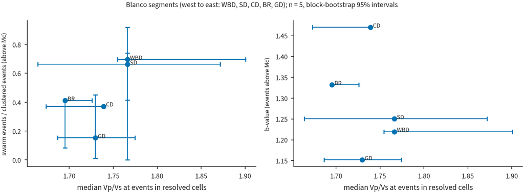

Blanco segments: median Vp/Vs at events in Vp/Vs-resolved cells against the swarm share of clustered events above Mc (left) and the b-value (right).

| segment | name | n_events | n_depth_good | n_resPS | pct_resPS | VpVs_events | VpVs_ci_lo | VpVs_ci_hi | dVp_events | dVs_events | depth_med | depth_good_med | n_aboveMc | swarm_share | swarm_ci_lo | swarm_ci_hi | background_share | n_fam5 | swarm_frac_fam5 | b_value |
| --- | --- | --- | --- | --- | --- | --- | --- | --- | --- | --- | --- | --- | --- | --- | --- | --- | --- | --- | --- | --- |
| WBD | West Blanco Depression | 13417 | 5498 | 1839 | 13.7 | 1.77 | 1.75 | 1.9 | -4.47 | -6.65 | 8.94 | 8.53 | 2174 | 0.696 | 0.414 | 0.919 | 0.436 | 27 | 0.815 | 1.22 |
| SD | Surveyor Depression | 8212 | 3778 | 567 | 6.9 | 1.77 | 1.66 | 1.87 | -0.733 | -6.65 | 8.39 | 8.42 | 1531 | 0.662 | 0 | 0.741 | 0.484 | 23 | 0.696 | 1.25 |
| CD | Cascadia Depression | 10338 | 3846 | 325 | 3.14 | 1.74 | 1.67 | 1.74 | -0.233 | -2.05 | 7.5 | 7.82 | 1409 | 0.372 | 0.372 | 0.372 | 0.5 | 35 | 0.629 | 1.47 |
| BR | Blanco Ridge | 6866 | 2533 | 1669 | 24.3 | 1.7 | 1.7 | 1.73 | -2.07 | -0.293 | 15.8 | 15.2 | 1135 | 0.412 | 0.0833 | 0.424 | 0.542 | 20 | 0.9 | 1.33 |
| GD | Gorda Depression | 4829 | 1926 | 425 | 8.8 | 1.73 | 1.69 | 1.77 | -4.17 | -5.42 | 12.8 | 11.5 | 1154 | 0.154 | 0.0112 | 0.451 | 0.747 | 17 | 0.412 | 1.15 |

| x | y | n_segments | spearman | p_exact |
| --- | --- | --- | --- | --- |
| VpVs_events | swarm_share | 5 | 0.667 | 0.267 |
| VpVs_events | background_share | 5 | -0.872 | 0.1 |
| VpVs_events | b_value | 5 | -0.154 | 0.833 |
| VpVs_events | swarm_frac_fam5 | 5 | -0.0513 | 1 |
| dVpVs_events | swarm_share | 5 | 0.3 | 0.683 |
| dVpVs_events | background_share | 5 | -0.6 | 0.35 |
| dVpVs_events | b_value | 5 | 0.2 | 0.783 |
| dVpVs_events | swarm_frac_fam5 | 5 | -0.3 | 0.683 |
| dVp_events | swarm_share | 5 | -0.3 | 0.683 |
| dVp_events | background_share | 5 | 0.1 | 0.95 |
| dVp_events | b_value | 5 | 0.8 | 0.133 |
| dVp_events | swarm_frac_fam5 | 5 | -0.2 | 0.783 |
| dVs_events | swarm_share | 5 | -0.564 | 0.4 |
| dVs_events | background_share | 5 | 0.667 | 0.267 |
| dVs_events | b_value | 5 | 0.564 | 0.4 |
| dVs_events | swarm_frac_fam5 | 5 | 0.154 | 0.833 |

Segments are longitude boxes along the transform, consistent with the literature names carried by the v1 Blanco surfaces (proposed decision). Only 3-24% of each segment's events are in Vp/Vs-resolved cells (the Cascadia Depression 3%). With five segments, the smallest possible two-sided exact p is 0.017, so a rank correlation cannot reach significance unless it is perfect. The segment values are not independent: the West Blanco and Surveyor medians are the same node value (1.7664), and 11 nodes hold 616 events of two segments. The pattern (higher Vp/Vs and more swarms in the west) agrees with the science-framing hypothesis, but the uncertainty intervals of neighbouring segments overlap.

### Forearc against slab; Mendocino triple junction; Mount St. Helens

| zone | rel | n | n_depth_good | depth_med | slab_med | dVp_res_mean | ci_lo | ci_hi | dVp_mean | Vp_med | n_blocks |
| --- | --- | --- | --- | --- | --- | --- | --- | --- | --- | --- | --- |
| MTJ | slab | 1135 | 906 | 28.5 | 13.2 | -0.42 | -0.854 | 0.202 | -0.789 | 8.02 | 7 |
| WA | upper plate | 10741 | 8487 | 8.61 | 55.6 | -0.979 | -1.32 | 0.221 | -0.962 | 6.23 | 29 |

| area | node_depth | n | n_nodes | n_blocks | dVp_mean | dVp_res_mean | ci_lo | ci_hi | null_lo | null_hi | p_perm |
| --- | --- | --- | --- | --- | --- | --- | --- | --- | --- | --- | --- |
| MSH (46.0-46.45 N, 122.4-122.0 W) | 1 | 2231 | 12 | 2 | -2.34 | -4.18 | -4.33 | 0.0413 | -5.85 | 6.24 | 0.293 |
| MSH (46.0-46.45 N, 122.4-122.0 W) | 3 | 760 | 18 | 2 | 3.5 | 1.6 | 1.55 | 2.02 | -3.94 | 2.83 | 0.399 |
| MSH (46.0-46.45 N, 122.4-122.0 W) | 5 | 1071 | 18 | 2 | -0.588 | 0.199 | 0.13 | 0.643 | -5.62 | 3.82 | 0.94 |
| MSH (46.0-46.45 N, 122.4-122.0 W) | 7 | 807 | 18 | 2 | -0.77 | -0.477 | -1.68 | -0.122 | -2.18 | 2.19 | 0.682 |
| MSH (46.0-46.45 N, 122.4-122.0 W) | 9 | 702 | 12 | 2 | -1.6 | -0.734 | -0.823 | -0.728 | -1.25 | 1.43 | 0.294 |
| MSH (46.0-46.45 N, 122.4-122.0 W) | 12 | 351 | 3 | 1 | -1.75 | -1.41 | -1.41 | -1.41 | -2.46 | 2.61 | 0.387 |
| MSH (46.0-46.45 N, 122.4-122.0 W) | 15 | 789 | 14 | 2 | -1.7 | -0.735 | -0.918 | 1.52 | -3.41 | 2.09 | 0.636 |
| MSH (46.0-46.45 N, 122.4-122.0 W) | 18 | 104 | 4 | 1 | -0.124 | 0.693 | 0.693 | 0.693 | -2.06 | 2.1 | 0.542 |
| SW Washington outside MSH box | 1 | 36 | 7 | 5 | -1.33 | 0.254 | -1.84 | 4.26 | -3.78 | 3.75 | 0.902 |
| SW Washington outside MSH box | 3 | 36 | 16 | 6 | -2.76 | -2.09 | -4.62 | 1.23 | -2.65 | 2.51 | 0.116 |
| SW Washington outside MSH box | 5 | 90 | 26 | 7 | -3.49 | -2.85 | -5.81 | 0.531 | -2.73 | 2.07 | 0.025 |
| SW Washington outside MSH box | 7 | 118 | 27 | 8 | -0.924 | -1.06 | -2.44 | 0.656 | -1.94 | 1.9 | 0.281 |
| SW Washington outside MSH box | 9 | 126 | 11 | 5 | 0.874 | -0.353 | -0.781 | 1.78 | -2.81 | 4.18 | 0.814 |
| SW Washington outside MSH box | 12 | 33 | 1 | 2 | 2.77 | 3.11 | 3.11 | 3.11 | -2.74 | 3.11 | 0.253 |
| SW Washington outside MSH box | 15 | 1043 | 62 | 14 | -0.035 | 0.872 | 0.421 | 1.6 | -0.922 | 0.853 | 0.0545 |
| SW Washington outside MSH box | 18 | 2444 | 148 | 24 | -1.23 | -0.505 | -0.809 | 0.00831 | -0.526 | 0.559 | 0.067 |
| MTJ 29 km north of 40.45 N | 29 | 1938 | 73 | 11 | 0.375 | 0.71 | -0.644 | 2.34 | -0.765 | 0.856 | 0.0885 |
| MTJ 29 km south of 40.45 N |  | 0 |  |  |  |  |  |  |  |  |  |

## 10. Circularity controls in detail

### Checkerboard inversion errors

| zone | var | n_cases | err_rms_med | event_mean_res_min | event_mean_res_max | event_mean_res_absmax | rho_min | rho_max | ploc_mean_res | swarm_minus_ma_absmax |
| --- | --- | --- | --- | --- | --- | --- | --- | --- | --- | --- |
| BL | dVp | 9 | 3.73 | -0.446 | 0.242 | 0.446 | -0.0628 | 0.0685 | -0.148 | 1.36 |
| BL | dVpVs | 9 | 3.41 | -0.467 | 0.794 | 0.794 | -0.0376 | 0.176 | 0.253 | 0.519 |
| BL | dVs | 9 | 3.27 | -1.21 | 0.522 | 1.21 | -0.228 | 0.114 | -0.414 | 1.36 |
| MTJ | dVp | 9 | 3.55 | -0.738 | 1.16 | 1.16 | -0.0652 | 0.193 | 0.5 |  |
| WA | dVp | 9 | 2.87 | -0.479 | 0.349 | 0.479 | -0.105 | 0.081 | -0.0496 |  |

err_rms: RMS error at resolved nodes (the checker amplitude is 8%). event_mean_res: the event-weighted coverage-matched mean of the error (what Q2 measures). swarm_minus_ma: the Q1 statistic on the error field. All 45 rows are in synth_artifact.csv.

### Location Monte Carlo (50 draws)

| statistic | catalog | mc_median | mc_p05 | mc_p95 |
| --- | --- | --- | --- | --- |
| pct_resP | 11 | 10.3 | 10.2 | 10.3 |
| pct_resPS | 2.87 | 2.92 | 2.86 | 2.97 |
| BL_dVp_res_mean | -1.81 | -1.34 | -1.45 | -1.23 |
| BL_Vp_res_mean | -0.12 | -0.0937 | -0.102 | -0.0862 |
| BL_dVs_res_mean | -2.85 | -1.95 | -2.06 | -1.86 |
| BL_VpVs_res_mean | 0.0247 | 0.0136 | 0.0118 | 0.0152 |
| BL_dVpVs_res_mean | 1.21 | 0.813 | 0.708 | 0.911 |
| MTJ_dVp_res_mean | 0.71 | 0.446 | 0.37 | 0.512 |
| MTJ_Vp_res_mean | 0.0269 | 0.000365 | -0.00565 | 0.00559 |
| WA_dVp_res_mean | -0.979 | -0.64 | -0.677 | -0.604 |
| WA_Vp_res_mean | -0.0622 | -0.0432 | -0.046 | -0.0401 |
| BL_swarm_minus_MA_VpVs_res | -0.00287 | -0.00331 | -0.0268 | 0.0205 |
| BL_n_swarm_fam | 24 | 31 | 26 | 37 |
| BL_n_MA_fam | 34 | 32 | 27.9 | 38.1 |
| BL_swarm_minus_MA_dVp_res | 0.262 | 0.247 | -0.00812 | 1.04 |

Resampling the locations changes the share of events in Vp-resolved cells from 11.0% to 10.3%. It shrinks the Blanco anomalies (Vp change -1.81 to -1.34%, Vs change -2.85 to -1.95%) because events scattered by their errors land in neighbouring nodes. This is consistent with an association at the catalog positions and on scales near the location error. It resamples random errors only; a systematic depth error (control 1) is not simulated.

## 11. v4-era counterpart

The earlier analysis, phase13_tomography.py (Route A era, 09-29), compared an earlier catalog with external Vs models (Delph et al. 2018; CRESCENT CVM Gen0). It used dlnVs relative to each model's depth mean and no resolution mask or coverage control. Its statistic, rerun on the v4 and the v5.1 hypocentres of the same events, shows what the relocation changed. The v4 counterpart on our own tomography is control 1 of section 6.

| model | group | n | baseline_median | median_v4 | median_v51 | change | depth_med_v4 | depth_med_v51 | depth_shift_med | frac_slow_v4 | frac_slow_v51 | n_group_all | depth_med_v4_all | depth_med_v51_all | depth_shift_med_all |
| --- | --- | --- | --- | --- | --- | --- | --- | --- | --- | --- | --- | --- | --- | --- | --- |
| CRESCENT_Gen0.nc | all located earthquakes | 93132 | -0.0352 | 4.46 | 4.97 | 0.502 | 17.3 | 19 | 1.96 | 0.268 | 0.217 | 1.68e+05 | 10.3 | 12.3 | 2.57 |
| CRESCENT_Gen0.nc | Blanco | 9389 | -0.0352 | 10.6 | 15 | 4.41 | 9.3 | 15.6 | 7.12 | 0.173 | 0.0658 | 4.23e+04 | 9.16 | 9.31 | 4.31 |
| CRESCENT_Gen0.nc | Cascades | 12494 | -0.0352 | 5.31 | 5.66 | 0.353 | 7.86 | 9.97 | 1.48 | 0.171 | 0.146 | 1.67e+04 | 4.73 | 7.1 | 1.7 |
| CRESCENT_Gen0.nc | Gorda | 9827 | -0.0352 | 11.6 | 10.1 | -1.49 | 22.7 | 25.3 | 3.32 | 0.139 | 0.102 | 1.14e+04 | 21.2 | 24.7 | 4.69 |
| CRESCENT_Gen0.nc | JdF ridge/plate | 88 | -0.0352 | -0.579 | -1.17 | -0.588 | 31.6 | 39.6 | 11.1 | 0.534 | 0.568 | 2.84e+03 | 5.07 | 3.34 | 3.25 |
| CRESCENT_Gen0.nc | Mendocino | 23451 | -0.0352 | 6.39 | 7.15 | 0.764 | 21.3 | 23.7 | 2.56 | 0.259 | 0.192 | 2.46e+04 | 21.1 | 23.4 | 2.66 |
| CRESCENT_Gen0.nc | Offshore forearc | 12363 | -0.0352 | 2.74 | 3.22 | 0.475 | 19.2 | 19.6 | 1.28 | 0.402 | 0.325 | 1.38e+04 | 18.7 | 19.6 | 1.61 |
| CRESCENT_Gen0.nc | Other onshore | 12319 | -0.0352 | 1.42 | 1.71 | 0.292 | 15.5 | 17.3 | 1.77 | 0.388 | 0.338 | 1.39e+04 | 14.5 | 16.3 | 2.05 |
| CRESCENT_Gen0.nc | Puget/Georgia | 13192 | -0.0352 | 2.31 | 2.09 | -0.217 | 15.4 | 15.5 | 0.418 | 0.298 | 0.303 | 1.44e+04 | 14.6 | 14.9 | 0.732 |
| CRESCENT_Gen0.nc | v5.1 events in Vp/Vs-resolved cells: Spearman(external dlnVs, v0.3.1 dVs_res) | 1993 |  |  | 20 | 0.16 |  |  |  |  |  |  |  |  |  |
| Delph2018.nc | all located earthquakes | 50562 | -0.0455 | 3.11 | 3.67 | 0.558 | 16.6 | 17.7 | 1.54 | 0.342 | 0.293 | 1.68e+05 | 10.3 | 12.3 | 2.57 |
| Delph2018.nc | Cascades | 12006 | -0.0455 | 4.48 | 3.94 | -0.548 | 8 | 10.1 | 1.48 | 0.0981 | 0.129 | 1.67e+04 | 4.73 | 7.1 | 1.7 |
| Delph2018.nc | Mendocino | 13921 | -0.0455 | 3.82 | 6.49 | 2.67 | 20.5 | 22.5 | 2.23 | 0.397 | 0.275 | 2.46e+04 | 21.1 | 23.4 | 2.66 |
| Delph2018.nc | Offshore forearc | 4365 | -0.0455 | -2.31 | 0.385 | 2.69 | 18.5 | 19.3 | 1.15 | 0.621 | 0.475 | 1.38e+04 | 18.7 | 19.6 | 1.61 |
| Delph2018.nc | Other onshore | 10318 | -0.0455 | 4.04 | 5.12 | 1.08 | 15.9 | 18 | 2 | 0.324 | 0.263 | 1.39e+04 | 14.5 | 16.3 | 2.05 |
| Delph2018.nc | Puget/Georgia | 9952 | -0.0455 | 0.578 | 0.478 | -0.0997 | 16.5 | 16.2 | 0.305 | 0.459 | 0.466 | 1.44e+04 | 14.6 | 14.9 | 0.732 |

The relocation moves Blanco events into faster CRESCENT Vs (+4.4 points in median dlnVs). This statistic uses only the 9,389 of 42,349 Blanco events that lie inside CRESCENT at both positions, and those moved deeper (median 9.3 to 15.6 km). For all Blanco events the medians are 9.2 and 9.3 km, with a paired median shift of +4.3 km. In the other regions the median changes by -1.5 to +0.8 points (CRESCENT) and -0.5 to +2.7 points (Delph). These numbers mostly follow depth and geography. The external models are not affected by the circularity of our own tomography, but they have no resolution information at the event scale either. At the 1,993 Vp/Vs-resolved v5.1 events inside CRESCENT, its dlnVs and our coverage-matched Vs change correlate weakly (Spearman 0.16). CRESCENT Gen0 Vs is part of our starting model onshore (D-B005); at the Blanco the start is Kuna et al. (2019).

## 12. What cannot be tested

| question | why |
| --- | --- |
| Vp/Vs anywhere outside the Blanco 15-18 km layer | Vs is reverted (dws_s < 10) or unresolved at 664 of the 888 Vp-resolved nodes |
| Axial, Endeavour, Explorer, JdF ridge and plate (19% of located earthquakes) | no resolved node (ridges_north left out of the merge, D-B050) |
| Gorda ridge and plate, Mendocino above 29 km; offshore Oregon and Washington forearc | no resolved node (s480 tiles barely recover checkerboards, D-B049) |
| Crust at the Blanco (above 13.5 km) | no resolved node at 1-12 km offshore |
| Q3 depth extent against a Vp level | 0-6 columns per zone with resolved Vp bracketing D90/D95 |
| Forearc against slab at matched depth and coverage | each resolved zone holds one population only |
| Contrast across the Mendocino fault | no resolved node south of 40.45 N |
| Swarm diffusion or migration against Vp/Vs | 88% of swarms are unresolved in migration (clusters piece) |
| Mount St Helens deep seismicity (review P1) | below the resolved depths; likely false events |
| Ensemble (posterior) uncertainty of the velocities (D-B037) | the D-B030 ensemble is not run on v0.3.1; the intervals here are spatial bootstrap intervals, not model posteriors |
| Fault-zone volume averages (D-B037) | volume widths from spike half-widths not yet set; at 40-60 km resolution a fault-zone volume is a single node |

## 13. Proposed decisions

1. Resolved means resolution_p > 0 for Vp; Vs and Vp/Vs both use the nodes resolved for both phases (resolution_p > 0, resolution_s > 0 and vs_reverted == 0), on v0.3.1 as published. The 12/21/25 km mask gaps are not bridged, and no DWS-only or tile-weight criterion is added.
2. Events are sampled at the nearest node (voxel). The all-eight-corners rule is reported as a stricter count, not used for the tests.
3. Circularity control: coverage-matched anomalies within zone x depth node x DWS tercile (P DWS for Vp, S DWS for Vs and Vp/Vs); randomized catalogs that move each node's event set to a random node of the same stratum; family types permuted within strata; 40 km block bootstrap (finest resolved checkerboard cell) for all intervals.
4. Use the tiles' checkerboard inversion errors (recovered minus true, noise and noise_ploc, both pattern phases) as the artefact yardstick, interpolated from the tile lattices onto the merged grid.
5. Event set: located earthquakes only (no loc_source none, no is_earthquake False). Depth-sensitive variants use depth_good (tier A-C, depth_quality ok, not floor_limited, far_only or deep_pass), the clusters piece's definition. A result that changes sign with depth_good (Mendocino Vp change) is reported as not robust.
6. Q1 family value: median over members in resolved cells, families with >= 3 such members; >= 50% (strict) and depth_good variants are reported. What a null result excludes is stated from the block-bootstrap interval, never from the permutation range.
7. b-value: Aki-Utsu on M minus the Mc of the event's cluster box, events split at a coverage-matched anomaly of 0. Report only within a zone (D-B041).
8. Blanco segments as longitude boxes (lat 42.4-45.0): WBD < -129.45 < SD < -128.95 < CD < -128.5 < BR < -127.45 < GD < -126.4, matching the v1 surfaces' literature names.
9. Q3 depth extent: columns of one model node (0.125 x 0.1 deg) with >= 30 well-constrained events; Vp at D90/D95 only between two adjacent resolved depth nodes.
10. Q4: constrained mesh vertices only; alignment of the horizontal normal with the horizontal gradient against random strike rotations; orientation results read only for the faults piece's 'stable' surfaces.
11. Multiple testing: Benjamini-Hochberg within a primary family that holds every computed main-set test, including the background-only b-value splits; q over primary plus variant sets reported alongside; a 'signal' column groups correlated tests, and passes are counted by signal as well as by test.
12. Test every relation also on the field smoothed to the resolved scale (Gaussian, sigma 20 km = half the finest resolved checkerboard cell) and on tile inversions with stronger smoothing; a relation that the checkerboards do not certify is reported as unresolved.
13. A node-scale event-velocity association is reported with four controls: hypocentres not located in the model (v4), each occupied node counted once, several block-grid placements, and tile runs with other smoothing or picks.
14. Do not use this analysis for interpretation in the paper beyond the statement of what is untestable and the null results at the resolved scale (with their bootstrap intervals). Redo it on catalog v6.0 (D-B079) with model v0.4.x (D-B082/D-B083) once its resolution tests (including a 20 km checkerboard or spike test at the Blanco) and its ensemble exist.

## 14. Open issues and limits

- The resolved volume is small: about 53 independent Vp cells and 14 Vp/Vs cells summed over depth nodes, or 25 and 8.5 counting the largest layer per zone. The D-B049 gate keeps the s480 tiles at full weight, but their checkerboards barely recover, so Gorda, Oregon and Washington are largely unresolved. Any structure-seismicity claim outside the Blanco needs a less smoothed or re-inverted model with new resolution tests.
- The checkerboard masks are empty at 21 and 25 km, and at 12 km except four Washington nodes, while neighbouring depths are resolved (tomography notes: probably the vertical checker sign changes). If the masks change, rerun every step (run_all.sh).
- The Blanco low-Vp/low-Vs association at the events is not certified by the 40-100 km resolution tests. Its Vp part follows the v5.1 depths (it nearly vanishes with the v4 hypocentres), so a trade-off with the v5.1 Blanco depths (+2.9 km median against Lange 2026; tensor events a median 13.7 km deeper than ComCat, review P3) is possible. Its Vs part persists with the v4 hypocentres and with the re-timed picks (v0.4.0's Blanco tile), and in value with stronger smoothing (whose intervals include zero). Counting each occupied node once leaves little of either part, and the event-weighted interval depends on the block-grid placement. A 20 km checkerboard or spike test and a synthetic with a systematic depth offset, on v0.4.x and catalog v6.0, would settle it.
- The Washington background-event b-value split by Vp (+0.49 [+0.06, +0.76], q 0.013 in the primary family) passes the rule but is one of 20 b-value splits and is not matched by the Vp-change split. Recheck on catalog v6.0 and v0.4.x before any reading.
- Vp/Vs at the Blanco (1.62-1.88 at resolved nodes) is close to the Kuna (2019) starting value of 1.73 in the mantle. Vs is reverted at most S-poor nodes (D-B051), so the Vp/Vs signal is weak by construction.
- Family labels at the Blanco: a whole-period time shuffle reproduces 39% of the links but only 12.8 of 70 swarms (clusters piece null test); Q1 inherits that uncertainty for the mainshock-aftershock and multiplet labels.
- Magnitudes: the phase19 ML inversion is not converged (mag piece); production M is unchanged pending a PI decision. Converged, offshore ML moves by region (Blanco -0.68), which would change which events are above the box Mc in the Blanco b-value and segment statistics.
- Waveform review P1-P4 is pending human review. None of the P1 deep or P2 Brookings events is in a resolved cell, but they set the deepest Q3 columns; 30 far_only events (29 Blanco) and 10 tensor events are in resolved cells.
- No ensemble posterior (D-B030/D-B032) exists for v0.3.1, so the velocity uncertainty at a node is not in the intervals; the block bootstrap covers spatial sampling only.
- All v5.1 products will be redone on catalog v6.0 (D-B079, NonLinLoc with SSST station terms), with model v0.4.0 (adopted, D-B082) or v0.4.1 (D-B083, being built).

## 15. All tests

family primary: 87 tests, q_BH within them; family variant: the other computed sets; q_BH_all over all 193. passed / passed_all: q below 0.05 and a block-bootstrap interval excluding the no-effect value (ref).

| family | question | zone | test | signal | n | effect | ci_lo | ci_hi | null_lo | null_hi | p | q_BH | q_BH_all | ref | passed | passed_all |
| --- | --- | --- | --- | --- | --- | --- | --- | --- | --- | --- | --- | --- | --- | --- | --- | --- |
| primary | Q1 swarms vs mainshock-aftershock | BL | swarm - mainshock-aftershock: VpVs_res | Q1 BL swarm - mainshock-aftershock | 24 vs 34 families, 11 blocks | -0.00287 | -0.0417 | 0.136 | -0.0611 | 0.0611 | 0.934 | 1 | 0.997 | 0 | False | False |
| primary | Q1 swarms vs mainshock-aftershock | BL | swarm - multiplet: VpVs_res | Q1 BL swarm - multiplet | 24 vs 18 families, 11 blocks | -0.0554 | -0.168 | 0.0213 | -0.0671 | 0.0741 | 0.155 | 0.421 | 0.357 | 0 | False | False |
| primary | Q1 swarms vs mainshock-aftershock | BL | swarm - mainshock-aftershock: dVpVs_res | Q1 BL swarm - mainshock-aftershock | 24 vs 34 families, 11 blocks | -0.183 | -2.36 | 6.59 | -2.89 | 2.83 | 0.895 | 1 | 0.992 | 0 | False | False |
| primary | Q1 swarms vs mainshock-aftershock | BL | swarm - multiplet: dVpVs_res | Q1 BL swarm - multiplet | 24 vs 18 families, 11 blocks | -2.48 | -8.37 | 0 | -3.78 | 3.74 | 0.179 | 0.472 | 0.402 | 0 | False | False |
| primary | Q1 swarms vs mainshock-aftershock | BL | swarm - mainshock-aftershock: dVs_res | Q1 BL swarm - mainshock-aftershock | 24 vs 34 families, 11 blocks | 1.37 | -3.19 | 3.71 | -1.57 | 2.28 | 0.197 | 0.505 | 0.428 | 0 | False | False |
| primary | Q1 swarms vs mainshock-aftershock | BL | swarm - multiplet: dVs_res | Q1 BL swarm - multiplet | 24 vs 18 families, 11 blocks | 1.37 | -2.94 | 4.86 | -3.18 | 2.09 | 0.317 | 0.626 | 0.561 | 0 | False | False |
| primary | Q1 swarms vs mainshock-aftershock | BL | swarm - mainshock-aftershock: dVp_res | Q1 BL swarm - mainshock-aftershock | 24 vs 34 families, 11 blocks | 0.262 | -3.77 | 3.83 | -1.76 | 1.03 | 0.586 | 0.944 | 0.844 | 0 | False | False |
| primary | Q1 swarms vs mainshock-aftershock | BL | swarm - multiplet: dVp_res | Q1 BL swarm - multiplet | 24 vs 18 families, 11 blocks | 0 | -9.45 | 1.29 | -1.97 | 2.03 | 1 | 1 | 1 | 0 | False | False |
| variant | Q1 swarms vs mainshock-aftershock | BL | swarm - mainshock-aftershock: VpVs_res (set resPS_dg) | Q1 BL swarm - mainshock-aftershock | 11 vs 26 families, 10 blocks | -0.00227 | -0.0919 | 0.145 | -0.099 | 0.132 | 0.915 |  | 0.995 | 0 | False | False |
| variant | Q1 swarms vs mainshock-aftershock | BL | swarm - multiplet: VpVs_res (set resPS_dg) | Q1 BL swarm - multiplet | 11 vs 10 families, 10 blocks | -0.084 | -0.214 | 0.0619 | -0.155 | 0.136 | 0.286 |  | 0.526 | 0 | False | False |
| variant | Q1 swarms vs mainshock-aftershock | BL | swarm - mainshock-aftershock: dVpVs_res (set resPS_dg) | Q1 BL swarm - mainshock-aftershock | 11 vs 26 families, 10 blocks | -2.45 | -6.96 | 8.83 | -4.73 | 6 | 0.272 |  | 0.524 | 0 | False | False |
| variant | Q1 swarms vs mainshock-aftershock | BL | swarm - multiplet: dVpVs_res (set resPS_dg) | Q1 BL swarm - multiplet | 11 vs 10 families, 10 blocks | -5.53 | -12.3 | 3.77 | -8.42 | 6.55 | 0.223 |  | 0.469 | 0 | False | False |
| variant | Q1 swarms vs mainshock-aftershock | BL | swarm - mainshock-aftershock: dVs_res (set resPS_dg) | Q1 BL swarm - mainshock-aftershock | 11 vs 26 families, 10 blocks | -1.34 | -8.33 | 5.28 | -4.59 | 4.22 | 0.447 |  | 0.71 | 0 | False | False |
| variant | Q1 swarms vs mainshock-aftershock | BL | swarm - multiplet: dVs_res (set resPS_dg) | Q1 BL swarm - multiplet | 11 vs 10 families, 10 blocks | -0.909 | -8.33 | 9.19 | -5.37 | 4.93 | 0.781 |  | 0.934 | 0 | False | False |
| variant | Q1 swarms vs mainshock-aftershock | BL | swarm - mainshock-aftershock: dVp_res (set resPS_dg) | Q1 BL swarm - mainshock-aftershock | 11 vs 26 families, 10 blocks | -1.15 | -4.4 | 2.82 | -5.23 | 1.62 | 0.569 |  | 0.839 | 0 | False | False |
| variant | Q1 swarms vs mainshock-aftershock | BL | swarm - multiplet: dVp_res (set resPS_dg) | Q1 BL swarm - multiplet | 11 vs 10 families, 10 blocks | 0.288 | -9.45 | 3.51 | -5.51 | 2.92 | 0.916 |  | 0.995 | 0 | False | False |
| variant | Q1 swarms vs mainshock-aftershock | BL | swarm - mainshock-aftershock: VpVs_res (set resPS_strict) | Q1 BL swarm - mainshock-aftershock | 6 vs 17 families, 8 blocks | -0.0401 | -0.177 | 0.0665 | -0.115 | 0.116 | 0.58 |  | 0.844 | 0 | False | False |
| variant | Q1 swarms vs mainshock-aftershock | BL | swarm - multiplet: VpVs_res (set resPS_strict) | Q1 BL swarm - multiplet | 6 vs 15 families, 8 blocks | -0.0984 | -0.235 | -0.0435 | -0.109 | 0.126 | 0.113 |  | 0.322 | 0 | False | False |
| variant | Q1 swarms vs mainshock-aftershock | BL | swarm - mainshock-aftershock: dVpVs_res (set resPS_strict) | Q1 BL swarm - mainshock-aftershock | 6 vs 17 families, 8 blocks | -1.15 | -8.18 | 4.24 | -7.97 | 7.37 | 0.784 |  | 0.934 | 0 | False | False |
| variant | Q1 swarms vs mainshock-aftershock | BL | swarm - multiplet: dVpVs_res (set resPS_strict) | Q1 BL swarm - multiplet | 6 vs 15 families, 8 blocks | -5.54 | -14.8 | -2.9 | -7.68 | 7.51 | 0.193 |  | 0.423 | 0 | False | False |
| variant | Q1 swarms vs mainshock-aftershock | BL | swarm - mainshock-aftershock: dVs_res (set resPS_strict) | Q1 BL swarm - mainshock-aftershock | 6 vs 17 families, 8 blocks | 7.2 | -1.43 | 12 | -3.38 | 7.34 | 0.029 |  | 0.117 | 0 | False | False |
| variant | Q1 swarms vs mainshock-aftershock | BL | swarm - multiplet: dVs_res (set resPS_strict) | Q1 BL swarm - multiplet | 6 vs 15 families, 8 blocks | 4.19 | 2.02 | 15.5 | -4.34 | 6.36 | 0.145 |  | 0.355 | 0 | False | False |
| variant | Q1 swarms vs mainshock-aftershock | BL | swarm - mainshock-aftershock: dVp_res (set resPS_strict) | Q1 BL swarm - mainshock-aftershock | 6 vs 17 families, 8 blocks | 5.28 | -1.22 | 5.99 | -4.66 | 4.11 | 0.0105 |  | 0.0482 | 0 | False | False |
| variant | Q1 swarms vs mainshock-aftershock | BL | swarm - multiplet: dVp_res (set resPS_strict) | Q1 BL swarm - multiplet | 6 vs 15 families, 8 blocks | 0.233 | -7.85 | 4.22 | -5.05 | 4.85 | 0.827 |  | 0.952 | 0 | False | False |
| variant | Q1 swarms vs mainshock-aftershock | BL | swarm - mainshock-aftershock: dVp_res (set resP) | Q1 BL swarm - mainshock-aftershock | 28 vs 38 families, 11 blocks | -0.00773 | -3.9 | 3.77 | -1.41 | 1.57 | 0.935 |  | 0.997 | 0 | False | False |
| variant | Q1 swarms vs mainshock-aftershock | BL | swarm - multiplet: dVp_res (set resP) | Q1 BL swarm - multiplet | 28 vs 21 families, 11 blocks | -0.194 | -9.45 | 1.29 | -1.47 | 2.35 | 0.821 |  | 0.952 | 0 | False | False |
| variant | Q1 swarms vs mainshock-aftershock | WA | swarm - mainshock-aftershock: dVp_res (set resP) | Q1 WA swarm - mainshock-aftershock | 15 vs 21 families, 9 blocks | 0 | -0.628 | 1.18 | -1.03 | 1.06 | 1 |  | 1 | 0 | False | False |
| variant | Q1 swarms vs mainshock-aftershock | WA | swarm - multiplet: dVp_res (set resP) | Q1 WA swarm - multiplet | 15 vs 14 families, 9 blocks | 1.43 | -0.734 | 3.31 | -0.913 | 1.47 | 0.036 |  | 0.14 | 0 | False | False |
| variant | Q1 swarms vs mainshock-aftershock | BL | swarm - mainshock-aftershock: dVp_res (set resP_dg) | Q1 BL swarm - mainshock-aftershock | 12 vs 27 families, 10 blocks | -1.57 | -4.61 | 2.82 | -2.51 | 3.65 | 0.343 |  | 0.602 | 0 | False | False |
| variant | Q1 swarms vs mainshock-aftershock | BL | swarm - multiplet: dVp_res (set resP_dg) | Q1 BL swarm - multiplet | 12 vs 12 families, 10 blocks | 0.647 | -9.45 | 3.53 | -2.93 | 4.8 | 0.741 |  | 0.93 | 0 | False | False |

[output cut: 163 more lines]

## 16. Files

In data/catalog_v5/v5.1_analysis/struct/: coverage_*.csv, flags_resolved_by_zone.csv, t1_*.csv, t2_*.csv (including t2_v4hypo.csv, t2_block_offsets*.csv, t2_tile_runs.csv, t2_bvalue_checks.csv), t3_*.csv, t4_*.csv, t5_*.csv, synth_artifact*.csv, mc_location*.csv, v4_counterpart_external_vs.csv, tests_summary.csv, nodes_resolved_v031.csv, events_in_resolved_cells.csv.gz, input_commits.json, fig_*.png. On /wd1/mdenolle_data/catalog_v5/v5.1_analysis/struct/: events_struct_v51.parquet, nodes_v031.parquet, RESUME.md, run_all.sh, logs, builder_tables (the first version's tables, for comparison).